# Phylogenetically-corrected AM orthogroup identification

2024-11-01

## Preface

The purpose of this script is to conduct validations of our results using phylogenetically-corrected models of protein size. We did not do this originally because this kind of model is very conservative and is finding universal AM-orthogroups which whether this is the correct approach for our study is questionable because AM+ status is the ancestral state from 450 million years ago so it’s been presumably been extensively modified in lineages over such a long time and would have been lost in multiple different ways in non-mycorrhizal plants. Nevertheless, doing this check is good since, if the results are consistent with this more conservative selection, then our results are robust.

The biggest change to our pipeline will just be the orthogroup classification into AM and not AM orthogroups. All the other data like which genes are context-dependently expressed, if they have sigantures of selection, etc. were all calculated without the AM orthogroup status. The AM orthogroup status was only used for mapping gene family sizes and doing the permutational correlation tests.

The assumed working directory is the validation_jobs folder which is above all the GOAL folders.

```r
library(phyr)
library(tidyr)
library(ape)
library(DESeq2)
library(dplyr)
library(reshape2)
```

```r
library(splitstackshape)
library(ggplot2)
library(car)
library(Hmisc)
```

## Orthogroup Selection

```r
#read in gene counts
gene_counts = read.csv("../GOAL2_orthogroup_analysis/Orthogroups.GeneCount.csv", sep = "\t")
colnames(gene_counts)[1] = "ortho"

#remove the total column
gene_counts$Total = NULL

#for phylogenetic models, convert data to long-form
gene_long = gene_counts %>%
  pivot_longer(!ortho, names_to = "species", values_to = "count")

#mycorrhizal status is just the first two characters of the species names
gene_long$myco = substr(gene_long$species, 1, 2)

#read in midpoint-rooted tree
spec_tree = read.tree("../GOAL2_orthogroup_analysis/Orthologues_Sep12/SpeciesTree_rooted_node_labels.txt")

#run phylogenetically-corrected model to ask which gene families change in size between AM and NM plants. since we are using count data, we will use a poisson distribution
#for this round I am using gaussian because poisson family fails when data is invariable in one of the groups (particularly when all NM are 0 which is the kind of orthogroup were interested in)
model_out = list(rep(0, length(unique(gene_long$ortho))))
for (i in 1:length(unique(gene_long$ortho))) {
  current_ortho = unique(gene_long$ortho)[i]
  model_out[[i]] = pglmm(count ~ myco + (1|species),
                       data = gene_long[gene_long$ortho == current_ortho,],
                       cov_ranef = list(species = spec_tree),
                       family = "gaussian")
}
```

```
## 'as(<matrix>, "dgTMatrix")' is deprecated.
## Use 'as(as(as(., "dMatrix"), "generalMatrix"), "TsparseMatrix")' instead.
## See help("Deprecated") and help("Matrix-deprecated").
```

```r
#save model p-values to dataframe
model_res = data.frame(matrix(nrow = length(unique(gene_long$ortho)), ncol = 3))
colnames(model_res) = c("ortho", "zscore", "pvalue")

model_res$ortho = unique(gene_long$ortho)
for (i in 1: length(unique(gene_long$ortho))) {
  model_res[i, 2] = model_out[[i]]$B.zscore[2]
  model_res[i, 3] = model_out[[i]]$B.pvalue[2]
}

#gene families that are invariable have model outputs that are NAs, let's convert the p-values to 1 and z-scores to 0 which is effectively what they are
model_res[is.na(model_res$pvalue), "pvalue"] = 1
model_res[is.na(model_res$zscore), "zscore"] = 0

model_res$fdr = p.adjust(model_res$pvalue, method = "fdr")

am_res = model_res[(model_res$fdr <= 0.05),]
am_res = am_res[(am_res$zscore < 0),]

#how different are these phylogenetically-corrected results from the original set?
og_am = read.csv("../GOAL2_orthogroup_analysis/orthogroups_mannwhitney_sig.csv")
og_am = og_am[(og_am$am_v_nm > 1),]

#remove plastid genes
gen_data = read.table("../GOAL3_context_dependent_expression_analysis/metadata/orthogroup_identified_AM_medicago_truncatula_genome_metadata.tsv",
                      sep = "\t", header = TRUE, comment.char = "", quote = "") #tell it to ignore the #
gen_data = gen_data[gen_data$X.Replicon.Name == "Pltd",]

am_res = am_res[!(am_res$ortho %in% gen_data$Orthogroup),]
og_am = og_am[!(og_am$X %in% gen_data$Orthogroup),]

length(intersect(am_res$ortho, og_am$X))
```

```
## [1] 381
```

```r
write.csv(am_res, "processed_data/am_res.csv", row.names = FALSE)
```

## Context-Dependent Expression Analyses

### Calabrese 2019 (Phosphorus, Populus trichocarpa)

```r
#clear environment
rm(list = ls())

#merge the two experimental dataframes of raw feature counts
featurecounts = read.csv("../GOAL3_context_dependent_expression_analysis/raw_data/calabrese_2019/GSE138316_Processed_Populus_preppedforinput.csv", row.names = 1, header = TRUE, sep = "\t")

#sum counts for each transcript to get values for gene
transcript_split = colsplit(row.names(featurecounts), "\\.", c("species", "gene", "transcript"))
featurecounts$gene_id = paste(transcript_split$species, transcript_split$gene, sep = ".")
featurecounts = featurecounts %>%
  group_by(gene_id) %>%
  summarise_all(list(sum))
featurecounts = as.data.frame(featurecounts)
row.names(featurecounts) = featurecounts$gene_id
featurecounts = featurecounts[, -c(1)]

#load metadata
exp_metadata = read.csv("../GOAL3_context_dependent_expression_analysis/metadata/calabrese2019_metadata.csv", header = TRUE, row.names = 1)

#put metadata in order of column names from gene counts matrix
all(rownames(exp_metadata) %in% colnames(featurecounts)) #check all samples are in counts
```

```
## [1] TRUE
```

```r
all(rownames(exp_metadata) == colnames(featurecounts)) #check samples are in order
```

```
## [1] TRUE
```

```r
featurecounts = featurecounts[, rownames(exp_metadata)] #put data in same order if the first is true but the second is false

#order factor levels for DESeq to know which is the reference group
exp_metadata$myco = factor(exp_metadata$myco, levels = c("control", "myco"))
exp_metadata$phosphorus = factor(exp_metadata$phosphorus, levels = c("high", "low"))

#load in orthogroup statistics to identify am-specific orthogroups
ortho = read.csv("processed_data/am_res.csv", header = TRUE)
am_ortho = ortho

#load data in to DESeq object
dds = DESeqDataSetFromMatrix(countData = featurecounts,
                                 colData = exp_metadata,
                                 design = ~myco*phosphorus
                                 )

#remove low count reads (optional, but I'm doing it)
keep = rowSums(counts(dds)) >= 10
dds = dds[keep,]

#perform differential expression analysis
dds_analysis = DESeq(dds, test = "LRT", reduced = ~1)
results = results(dds_analysis, alpha = 0.05)
int_analysis = DESeq(dds, test = "LRT", reduced = ~myco+phosphorus)
```

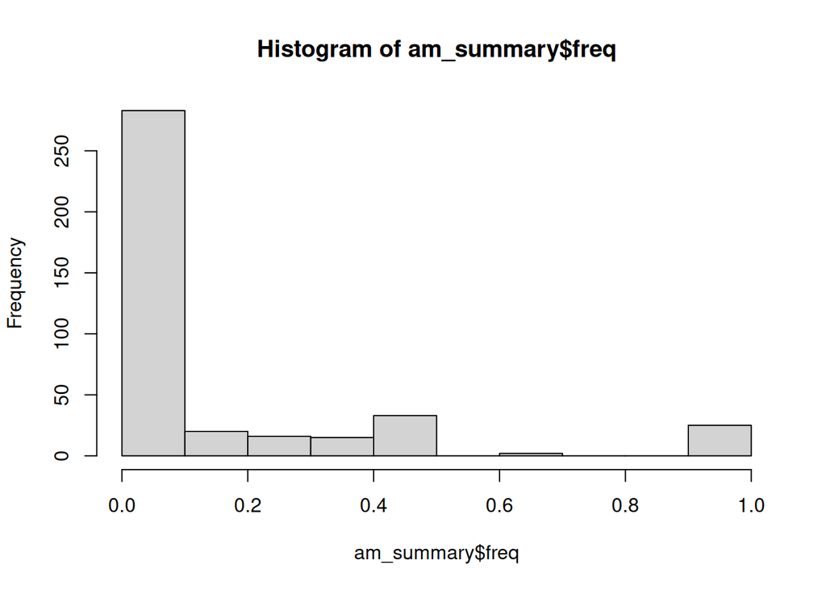

```r
int_results = results(int_analysis, alpha = 0.05)

#load in genome metadata
#note: there are duplicates because there are multiple isoforms for each gene in the genome metadata.
#fix by getting isoform with lowest e-value
gen_data = read.table("../GOAL3_context_dependent_expression_analysis/processed_data/20210718_populus_blast_with_orthogroup.tsv",
                      sep = "\t", header = TRUE, comment.char = "", quote = "") #tell it to ignore the #
gen_data = gen_data[order(gen_data$gene_stable_id, gen_data$evalue, decreasing = FALSE),] #sort by populus gene_stable_id to group genes together and then by evalue

gen_unique <- gen_data[!duplicated(gen_data$gene_stable_id),]

#remove plastid genes
med_ortho = read.csv("../GOAL3_context_dependent_expression_analysis/metadata/orthogroup_identified_AM_medicago_truncatula_genome_metadata.tsv", sep = "\t")
plastid = med_ortho[med_ortho$X.Replicon.Name == "Pltd",]
gen_unique = gen_unique[!(gen_unique$orthogroup %in% plastid$Orthogroup),]

#merge the rlog data with the genomic metadata
#note: some rna-seq reads aren't in the genomic metadata
#note2: I checked a random set of 10 and these genes don't have protein products because they're either pseudo-genes or non-coding RNA
int_results_df = as.data.frame(int_results)
int_composite = merge(int_results_df, gen_unique, by.x = 0, by.y = "gene_stable_id")
int_composite$de_sig = int_composite$padj <= .05
int_composite$de_sig[is.na(int_composite$de_sig)] = FALSE

#get gene counts per orthogroup in refseq
gene_counts = gen_unique %>%
                group_by(orthogroup) %>%
                dplyr::summarise(count = n())

am_gene_counts = gene_counts[gene_counts$orthogroup %in% am_ortho$ortho,]

#filter for results only in am-specific orthogroups
am_int = int_composite[int_composite$orthogroup %in% am_ortho$ortho,]

#add gene count info to am_int
am_int = merge(am_int, am_gene_counts, by = "orthogroup")

#add boolean column for whether genes were differentially expressed.
#used to calculate frequencies
am_int$de_sig = am_int$padj <= 0.05
am_int$de_sig[is.na(am_int$de_sig)] = FALSE

#summarise relationship between am-specific orthogroup size and significance
#mean is used on the count column because this is just duplicated for each orthogroup value
am_summary = am_int %>%
  group_by(orthogroup) %>%
  dplyr::summarise(de_count = sum(de_sig), freq = sum(de_sig)/mean(count), gene_count = mean(count))

#repeat summarization for full dataset to perform permutational analyses
int_composite = merge(int_composite, gene_counts, by = "orthogroup")
int_summary = int_composite %>%
  group_by(orthogroup) %>%
  dplyr::summarise(de_count = sum(de_sig), freq = sum(de_sig)/mean(count), gene_count = mean(count))

#Plot distributions of gene counts and frequencies in both summarizations to determine if parametric tests are appropriate or if permutational tests must be used
#AM DE Frequencies
hist(am_summary$freq)
```

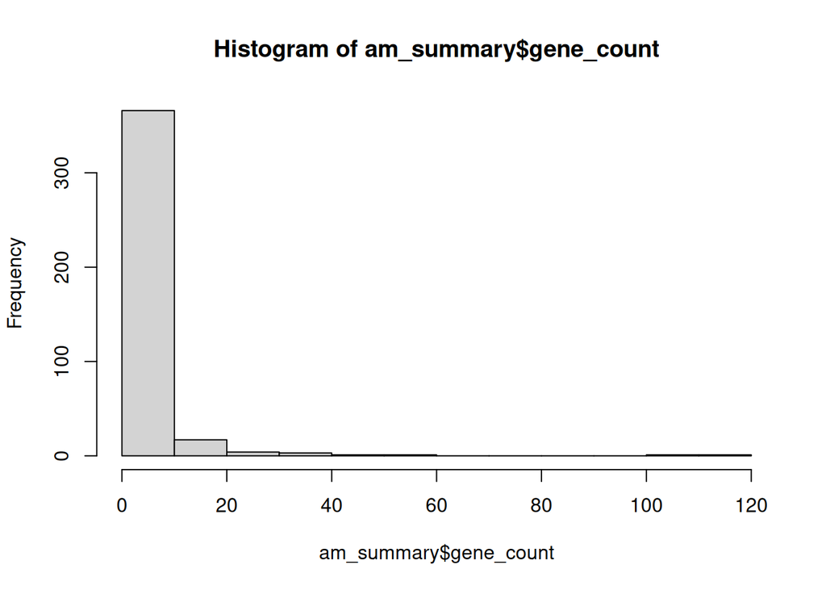

```r
#AM Gene Counts
hist(am_summary$gene_count)
```

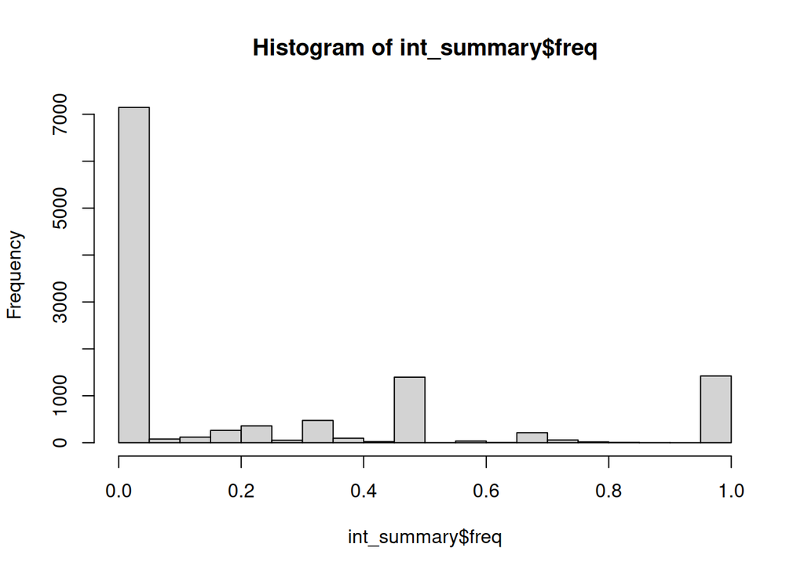

```r
#Complete dataset DE Frequencies
hist(int_summary$freq)
```

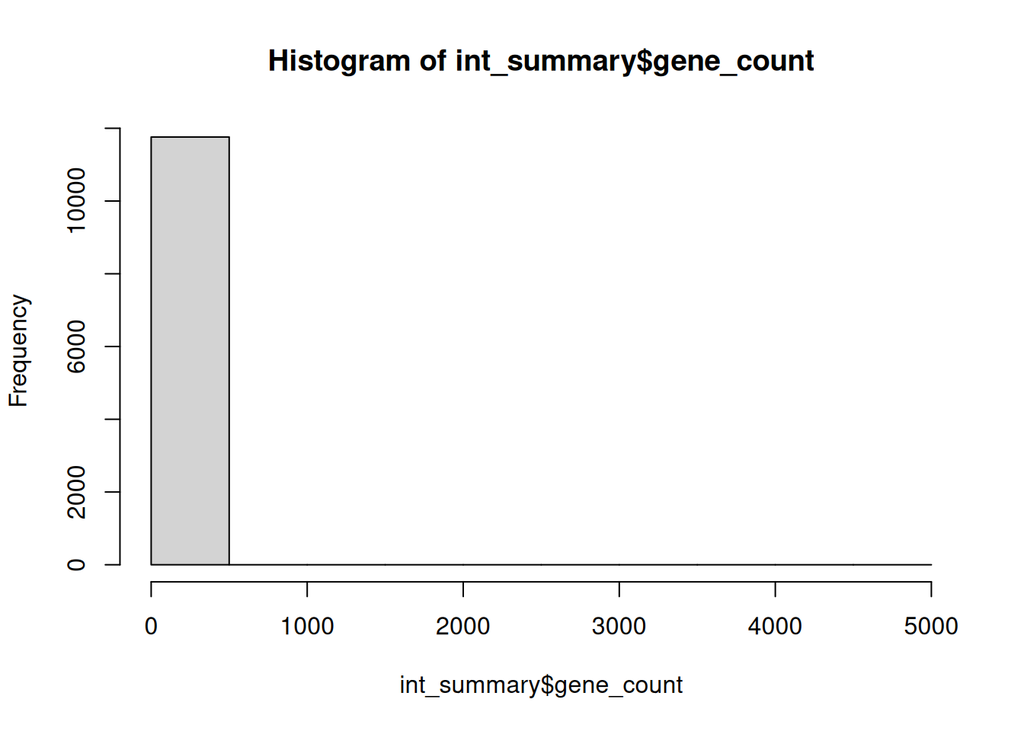

```r
#Complete dataset Gene Counts
hist(int_summary$gene_count)
```

```r
#All distributions are heavily skewed. So, parametric tests are not appropriate. Instead, perform permutations from observed distributions to determine if AM relationship is stronger than that observed in complete dataset. Perform permutations to observed if strength of AM relationship is stronger than random.

#observed relationship between am-specific orthogroup size and frequency of significant interactive expression
(freq_v_gen = cor.test(am_summary$freq, am_summary$gene_count, method = "spearman"))
```

```
##
##  Spearman's rank correlation rho
##
## data:  am_summary$freq and am_summary$gene_count
## S = 8009739, p-value = 1.794e-05
## alternative hypothesis: true rho is not equal to 0
## sample estimates:
##       rho
## 0.2142511
```

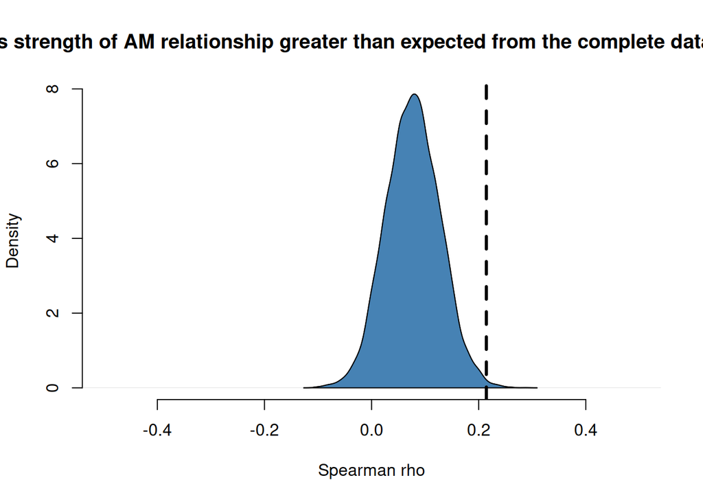

```r
#Is strength of AM relationship greater than expected from the complete dataset?
perm_rho = rep(0, 10000)
for (i in 1:10000) {
  random_df = int_summary[sample(1:nrow(int_summary), length(am_summary$orthogroup)),]
  holder = cor.test(random_df$freq, random_df$gene_count, method = "spearman")
  perm_rho[i] = holder$estimate[[1]]
}
perm_rho[is.na(perm_rho)] = 0 #some values may be NA. convert to zero which means no relationship.
dens = density(perm_rho)
plot(dens, xlim = c(-.5, .5), main = "Is strength of AM relationship greater than expected from the complete dataset?", xlab = "Spearman rho",
     frame = FALSE)
polygon(dens, col = "steelblue")
abline(v = freq_v_gen$estimate[[1]], col = "black", lwd = 3, lty = 2)
```

```r
(pvalue = sum(abs(freq_v_gen$estimate[[1]]) <= abs(perm_rho))/length(perm_rho))
```

```
## [1] 0.0038
```

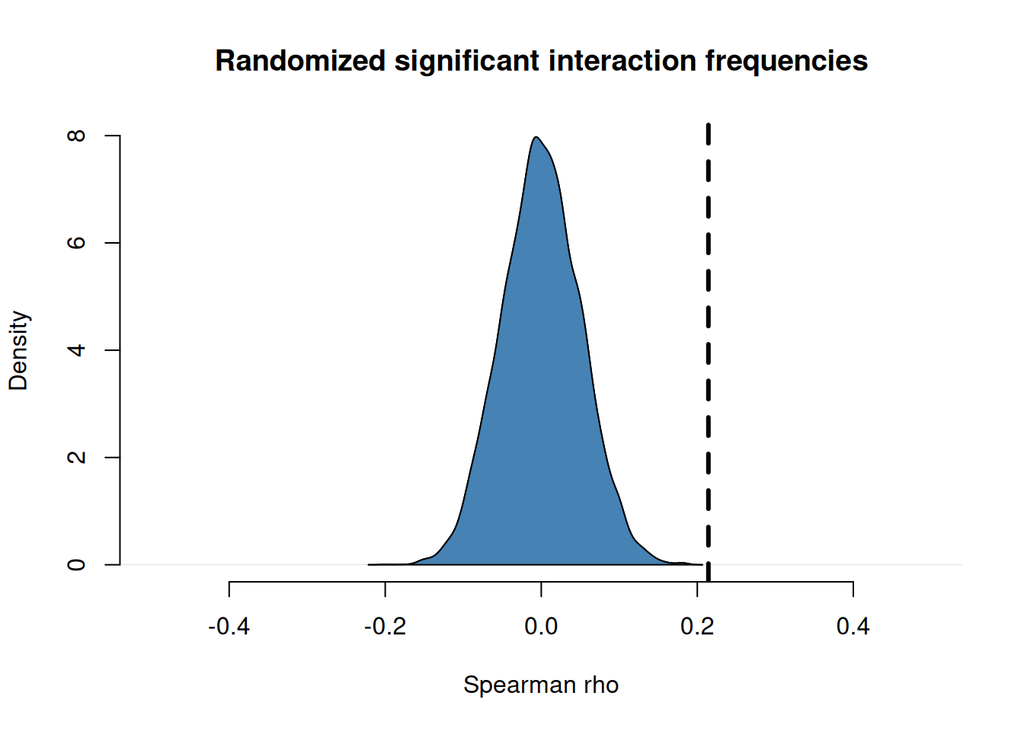

```r
#save this to dataframe for comparing all experiments later.
df_to_save = data.frame(perm_rho, rep(freq_v_gen$estimate, length(perm_rho)), rep("calabrese2019_root", length(perm_rho)))
colnames(df_to_save) = c("permuted_rho", "observed_rho", "data_source")
write.csv(df_to_save, "processed_data/calabrese2019_root.csv")

#Is strength of AM relationship greater than random?
perm_rho = rep(0, 10000)
for (i in 1:10000) {
  random_count = sample(am_summary$gene_count)
  holder = cor.test(am_summary$freq, random_count, method = "spearman")
  perm_rho[i] = holder$estimate[[1]]
}
dens = density(perm_rho)
plot(dens, xlim = c(-.5, .5), main = "Randomized significant interaction frequencies", xlab = "Spearman rho",
     frame = FALSE)
polygon(dens, col = "steelblue")
abline(v = freq_v_gen$estimate[[1]], col = "black", lwd = 3, lty = 2)
```

```r
(pvalue = sum(abs(freq_v_gen$estimate[[1]]) <= abs(perm_rho))/length(perm_rho))
```

```
## [1] 0
```

### Garcia 2017 (Potassium, Medicago truncatula)

```r
#clear environment
rm(list = ls())

#merge the two experimental dataframes of raw feature counts
featurecounts = read.csv("../GOAL3_context_dependent_expression_analysis/raw_data/garcia2017_featurecounts_refseq.txt", row.names = 1, header = TRUE, sep = "\t")
gene_metadata = featurecounts[, c(1:5)]
featurecounts = featurecounts[,-c(1:5)]

#replace column names to just have their SRR IDs to match with metadata
srr_names_unedit = colnames(featurecounts)
srr_names = sapply(strsplit(srr_names_unedit, ".", fixed = TRUE), "[", 2)
colnames(featurecounts) = srr_names

#load metadata
exp_metadata = read.csv("../GOAL3_context_dependent_expression_analysis/metadata/garcia2017_metadata.csv", header = TRUE, row.names = 1)

#put metadata in order of column names from gene counts matrix
all(rownames(exp_metadata) %in% colnames(featurecounts)) #check all samples are in counts
```

```
## [1] TRUE
```

```r
all(rownames(exp_metadata) == colnames(featurecounts)) #check samples are in order
```

```
## [1] FALSE
```

```r
featurecounts = featurecounts[, rownames(exp_metadata)] #put data in same order if the first is true but the second is false

#order factor levels for DESeq to know which is the reference group
exp_metadata$growth_protocol = factor(exp_metadata$growth_protocol, levels = c("control", "K"))
exp_metadata$inoculation = factor(exp_metadata$inoculation, levels = c("control", "R"))

#load in orthogroup statistics to identify am-specific orthogroups
ortho = read.csv("processed_data/am_res.csv")
am_ortho = ortho

#load data in to DESeq object
dds = DESeqDataSetFromMatrix(countData = featurecounts,
                                 colData = exp_metadata,
                                 design = ~growth_protocol*inoculation
                                 )

#remove low count reads (optional, but I'm doing it)
keep = rowSums(counts(dds)) >= 10
dds = dds[keep,]

#perform differential expression analysis
dds_analysis = DESeq(dds, test = "LRT", reduced = ~1)
results = results(dds_analysis, alpha = 0.05)
int_analysis = DESeq(dds, test = "LRT", reduced = ~growth_protocol+inoculation)
```

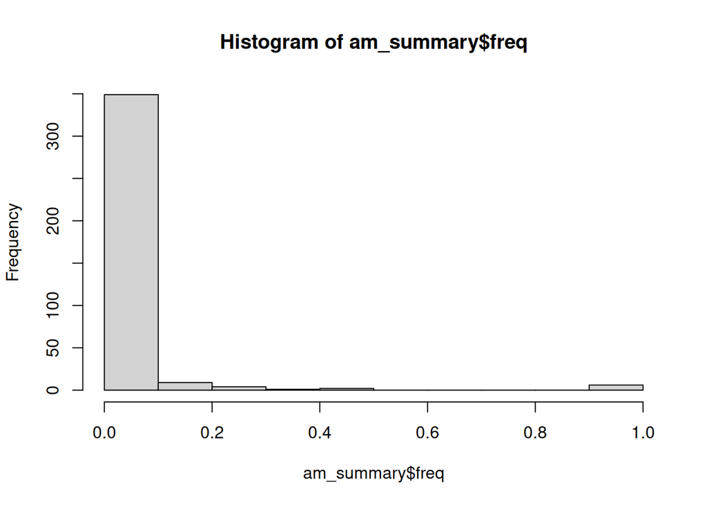

```r
int_results = results(int_analysis, alpha = 0.05)

#load in genome metadata
#note: there are duplicates because there are multiple isoforms for each gene in the genome metadata.
#fix by getting isoform with lowest e-value
gen_data = read.table("../GOAL3_context_dependent_expression_analysis/metadata/orthogroup_identified_AM_medicago_truncatula_genome_metadata.tsv",
                      sep = "\t", header = TRUE, comment.char = "", quote = "") #tell it to ignore the #

#remove plastid genes
gen_data = gen_data[gen_data$X.Replicon.Name != "Pltd",]

#create column for merging dataframes
gen_data$gene_locus = paste("gene-", gen_data$Locus, sep = "")

#merge the rlog data with the genomic metadata
#note: some rna-seq reads aren't in the genomic metadata
#note2: I checked a random set of 10 and these genes don't have protein products because they're either pseudo-genes or non-coding RNA
int_results_df = as.data.frame(int_results)
int_composite = merge(int_results_df, gen_data, by.x = 0, by.y = "gene_locus")
int_composite$de_sig = int_composite$padj <= .05
int_composite$de_sig[is.na(int_composite$de_sig)] = FALSE

#get gene counts per orthogroup in refseq
gene_counts = gen_data %>%
                group_by(Orthogroup) %>%
                dplyr::summarise(count = n())

am_gene_counts = gene_counts[gene_counts$Orthogroup %in% am_ortho$ortho,]

#filter for results only in am-specific orthogroups
am_int = int_composite[int_composite$Orthogroup %in% am_ortho$ortho,]

#add gene count info to am_int
am_int = merge(am_int, am_gene_counts, by = "Orthogroup")

#add boolean column for whether genes were differentially expressed.
#used to calculate frequencies
am_int$de_sig = am_int$padj <= 0.05
am_int$de_sig[is.na(am_int$de_sig)] = FALSE

#summarise relationship between am-specific orthogroup size and significance
#mean is used on the count column because this is just duplicated for each orthogroup value
am_summary = am_int %>%
  group_by(Orthogroup) %>%
  dplyr::summarise(de_count = sum(de_sig), freq = sum(de_sig)/mean(count), gene_count = mean(count))

#repeat summarization for full dataset to perform permutational analyses
int_composite = merge(int_composite, gene_counts, by = "Orthogroup")
int_summary = int_composite %>%
  group_by(Orthogroup) %>%
  dplyr::summarise(de_count = sum(de_sig), freq = sum(de_sig)/mean(count), gene_count = mean(count))

#Plot distributions of gene counts and frequencies in both summarizations to determine if parametric tests are appropriate or if permutational tests must be used
#AM DE Frequencies
hist(am_summary$freq)
```

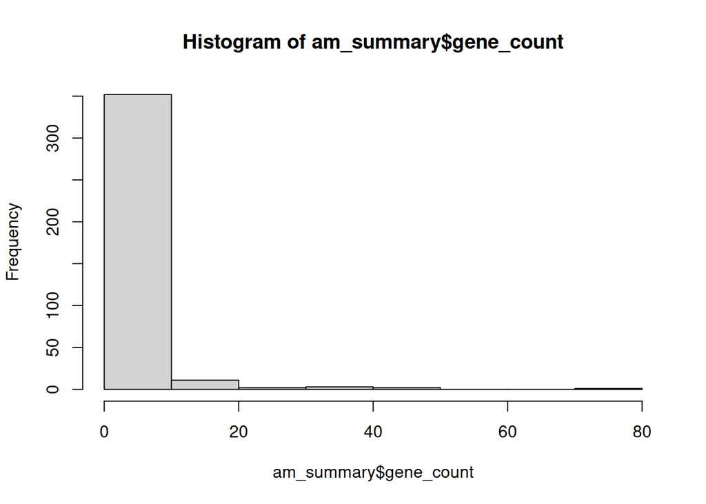

```r
#AM Gene Counts
hist(am_summary$gene_count)
```

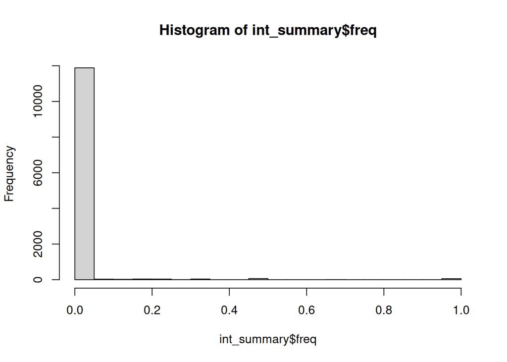

```r
#Complete dataset DE Frequencies
hist(int_summary$freq)
```

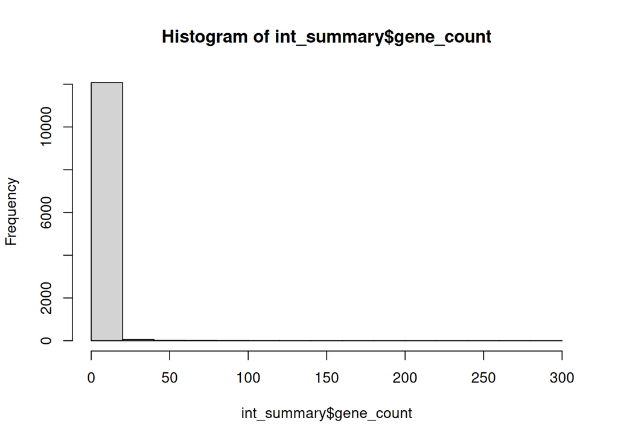

```r
#Complete dataset Gene Counts
hist(int_summary$gene_count)
```

```r
#All distributions are heavily skewed. So, parametric tests are not appropriate. Instead, perform permutations from observed distributions to determine if AM relationship is stronger than that observed in complete dataset. Perform permutations to observed if strength of AM relationship is stronger than random.

#observed relationship between am-specific orthogroup size and frequency of significant interactive expression
(freq_v_gen = cor.test(am_summary$freq, am_summary$gene_count, method = "spearman"))
```

```
##
##  Spearman's rank correlation rho
##
## data:  am_summary$freq and am_summary$gene_count
## S = 5915043, p-value = 1.995e-09
## alternative hypothesis: true rho is not equal to 0
## sample estimates:
##       rho
## 0.3049908
```

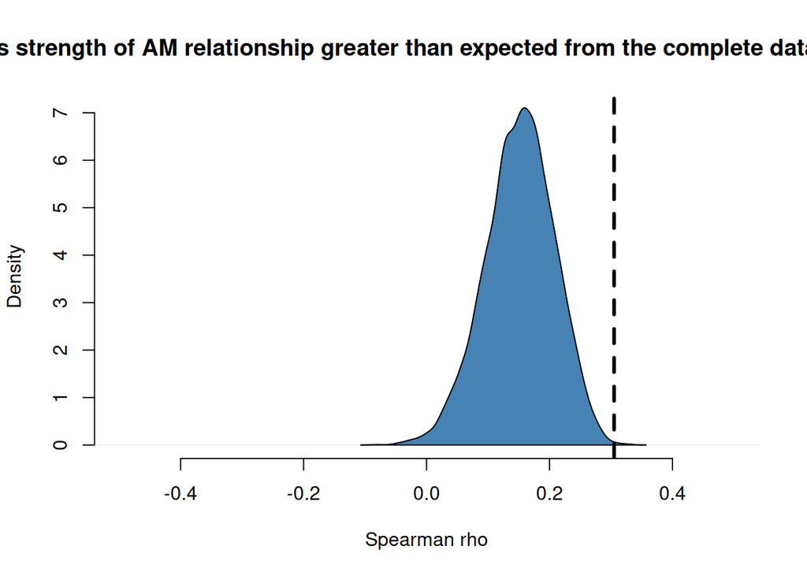

```r
#Is strength of AM relationship greater than expected from the complete dataset?
perm_rho = rep(0, 10000)
for (i in 1:10000) {
  random_df = int_summary[sample(1:nrow(int_summary), length(am_summary$Orthogroup)),]
  holder = cor.test(random_df$freq, random_df$gene_count, method = "spearman")
  perm_rho[i] = holder$estimate[[1]]
}
perm_rho[is.na(perm_rho)] = 0 #some values were NA. convert to zero which means no relationship.
dens = density(perm_rho)
plot(dens, xlim = c(-.5, .5), main = "Is strength of AM relationship greater than expected from the complete dataset?", xlab = "Spearman rho",
     frame = FALSE)
polygon(dens, col = "steelblue")
abline(v = freq_v_gen$estimate[[1]], col = "black", lwd = 3, lty = 2)
```

```r
(pvalue = sum(abs(freq_v_gen$estimate[[1]]) <= abs(perm_rho))/length(perm_rho))
```

```
## [1] 0.0011
```

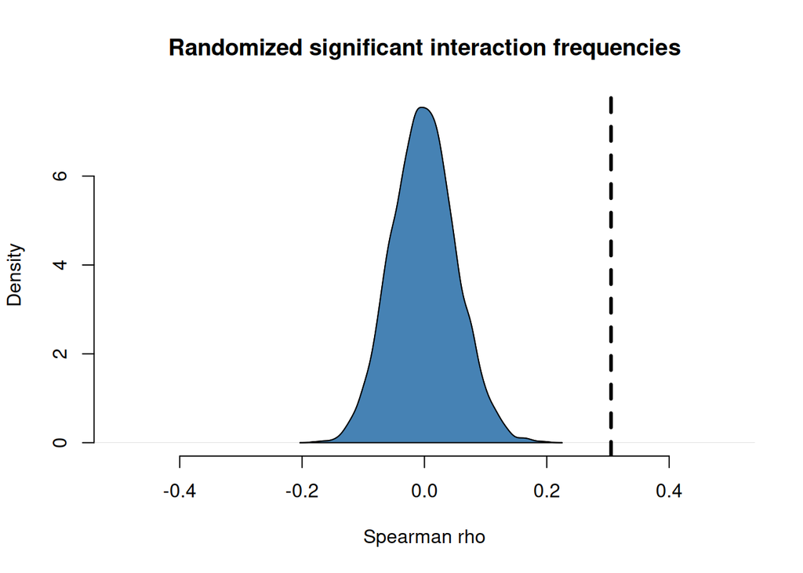

```r
#save this to dataframe for comparing all experiments later.
df_to_save = data.frame(perm_rho, rep(freq_v_gen$estimate, length(perm_rho)), rep("garcia2017_root", length(perm_rho)))
colnames(df_to_save) = c("permuted_rho", "observed_rho", "data_source")
write.csv(df_to_save, "processed_data/garcia2017_root.csv")

#Is strength of AM relationship greater than random?
perm_rho = rep(0, 10000)
for (i in 1:10000) {
  random_count = sample(am_summary$gene_count)
  holder = cor.test(am_summary$freq, random_count, method = "spearman")
  perm_rho[i] = holder$estimate[[1]]
}
dens = density(perm_rho)
plot(dens, xlim = c(-.5, .5), main = "Randomized significant interaction frequencies", xlab = "Spearman rho",
     frame = FALSE)
polygon(dens, col = "steelblue")
abline(v = freq_v_gen$estimate[[1]], col = "black", lwd = 3, lty = 2)
```

```r
(pvalue = sum(abs(freq_v_gen$estimate[[1]]) <= abs(perm_rho))/length(perm_rho))
```

```
## [1] 0
```

### Recchia 2018 (Drought, Phaseoulus vulgaris)

```r
#clear environment
rm(list = ls())

#merge the counts from the different dataframes
file_names = list.files("../GOAL3_context_dependent_expression_analysis/processed_data/recchia2018_pvulgaris_bam/", pattern = "*.tab")

df = data.frame(gene_id = character(),
                unstranded = numeric(),
                forward = numeric(),
                reverse = numeric(),
                sample_names = character())
for (i in file_names) {
  holder = read.table(paste("../GOAL3_context_dependent_expression_analysis/processed_data/recchia2018_pvulgaris_bam/", i, sep = ""), header = FALSE, sep = "\t")
  sample_temp = colsplit(rep(i, length(row.names(holder))), pattern = "_", names = c("study", "bam", "sample_name", "file_type"))
  holder$sample_name = sample_temp$sample_name
  holder = holder[5:length(row.names(holder)),] #remove the first four rows containing mapping info
  colnames(holder) = c("gene_id", "unstranded", "forward", "reverse", "sample_name")
  df = rbind(df, holder)
}

featurecounts_long = df[,c("gene_id", "unstranded", "sample_name")]
featurecounts = dcast(featurecounts_long, gene_id ~ sample_name, value.var = "unstranded")
row.names(featurecounts) = featurecounts$gene_id
featurecounts = featurecounts[,-c(1)]

#one sample was uploaded into SRA project even though it was not included in their analyses. It is the one with the disproportionately lowest number of bases (351 Mreads vs minimum of 1431M reads). Sample: SRR3215329
#load metadata
exp_metadata = read.csv("../GOAL3_context_dependent_expression_analysis/metadata/recchia2018_metadata_edited.csv", header = TRUE, row.names = 1)
exp_metadata = exp_metadata[row.names(exp_metadata) != "SRR3215329",]

#put metadata in order of column names from gene counts matrix
all(rownames(exp_metadata) %in% colnames(featurecounts)) #check all samples are in counts
```

```
## [1] TRUE
```

```r
all(rownames(exp_metadata) == colnames(featurecounts)) #check samples are in order
```

```
## [1] FALSE
```

```r
featurecounts = featurecounts[, rownames(exp_metadata)] #put data in same order if the first is true but the second is false

#order factor levels for DESeq to know which is the reference group
exp_metadata$myco = factor(exp_metadata$myco, levels = c("control", "myco"))
exp_metadata$drought = factor(exp_metadata$drought, levels = c("control", "drought"))

#load in orthogroup statistics to identify am-specific orthogroups
ortho = read.csv("processed_data/am_res.csv")
am_ortho = ortho

#load data in to DESeq object
#expected counts are outputs from RSEM according to Ren et al 2019. As a result, we can round them.
dds = DESeqDataSetFromMatrix(countData = round(featurecounts),
                                 colData = exp_metadata,
                                 design = ~myco*drought
                                 )
#remove low count reads (optional, but I'm doing it)
keep = rowSums(counts(dds)) >= 10
dds = dds[keep,]

#perform differential expression analysis
dds_analysis = DESeq(dds, test = "LRT", reduced = ~1)
results = results(dds_analysis, alpha = 0.05)
int_analysis = DESeq(dds, test = "LRT", reduced = ~myco+drought)
```

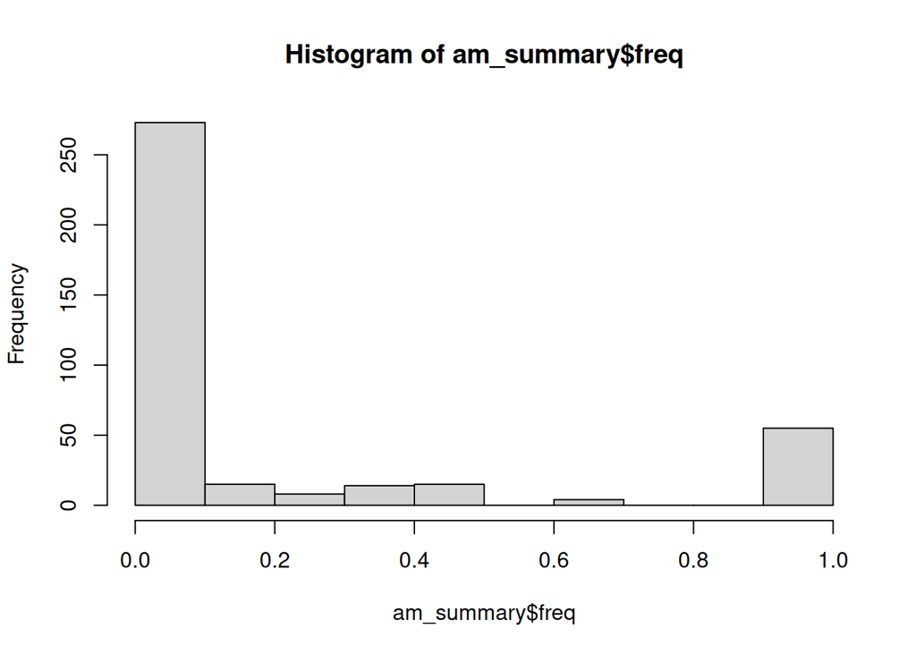

```r
int_results = results(int_analysis, alpha = 0.05)

#load in genome metadata
#note: there are duplicates because there are multiple isoforms for each gene in the genome metadata.
#fix by getting isoform with lowest e-value
gen_data = read.table("../GOAL3_context_dependent_expression_analysis/processed_data/20210823_phaseolus_blast_with_orthogroup.tsv", sep = "\t", header = TRUE)
gen_data = gen_data[order(gen_data$gene_stable_id, gen_data$evalue, decreasing = FALSE),] #sort by embl_gene to group genes together and then by evalue
gen_unique <- gen_data[!duplicated(gen_data$gene_stable_id),]

#remove plastid genes
med_ortho = read.csv("../GOAL3_context_dependent_expression_analysis/metadata/orthogroup_identified_AM_medicago_truncatula_genome_metadata.tsv", sep = "\t")
plastid = med_ortho[med_ortho$X.Replicon.Name == "Pltd",]
gen_unique = gen_unique[!(gen_unique$orthogroup %in% plastid$Orthogroup),]

#get gene counts per orthogroup in triticum
gene_counts = gen_unique %>%
                group_by(orthogroup) %>%
                dplyr::summarise(count = n())

am_gene_counts = gene_counts[gene_counts$orthogroup %in% am_ortho$ortho,]

#merge the deseq data with the genome metadata
int_results_df = as.data.frame(int_results)
int_composite = merge(int_results_df, gen_unique, by.x = 0, by.y = "gene_stable_id")

#filter for results only in am-specific orthogroups
am_int = int_composite[int_composite$orthogroup %in% am_ortho$ortho,]

#add gene count info to am_int
am_int = merge(am_int, am_gene_counts, by = "orthogroup")

#add boolean column for whether genes were differentially expressed.
#used to calculate frequencies
am_int$de_sig = am_int$padj <= 0.05
am_int$de_sig[is.na(am_int$de_sig)] = FALSE

#summarise relationship between am-specific orthogroup size and significance
#mean is used on the count column because this is just duplicated for each orthogroup value
am_summary = am_int %>%
  group_by(orthogroup) %>%
  dplyr::summarise(de_count = sum(de_sig), freq = sum(de_sig)/mean(count), gene_count = mean(count))

#repeat summarization for full dataset to perform permutational analyses
int_composite = merge(int_composite, gene_counts, by = "orthogroup")
int_composite$de_sig = int_composite$padj <= 0.05
int_composite$de_sig[is.na(int_composite$de_sig)] = FALSE
int_summary = int_composite %>%
  group_by(orthogroup) %>%
  dplyr::summarise(de_count = sum(de_sig), freq = sum(de_sig)/mean(count), gene_count = mean(count))

#Plot distributions of gene counts and frequencies in both summarizations to determine if parametric tests are appropriate or if permutational tests must be used
#AM DE Frequencies
hist(am_summary$freq)
```

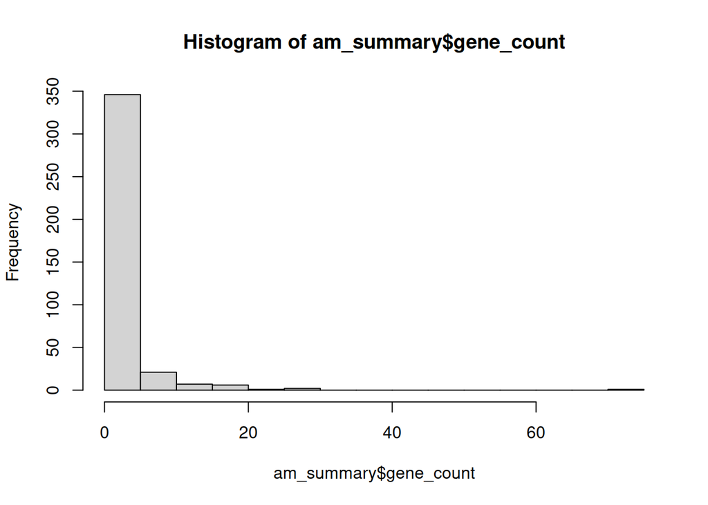

```r
#AM Gene Counts
hist(am_summary$gene_count)
```

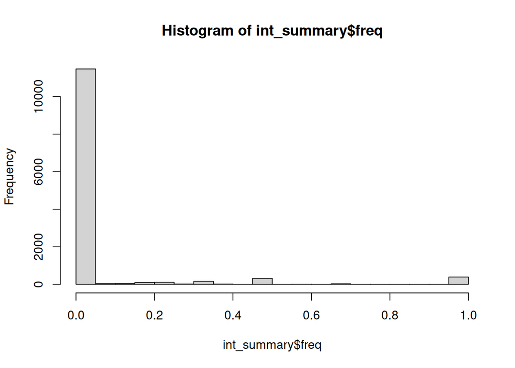

```r
#Complete dataset DE Frequencies
hist(int_summary$freq)
```

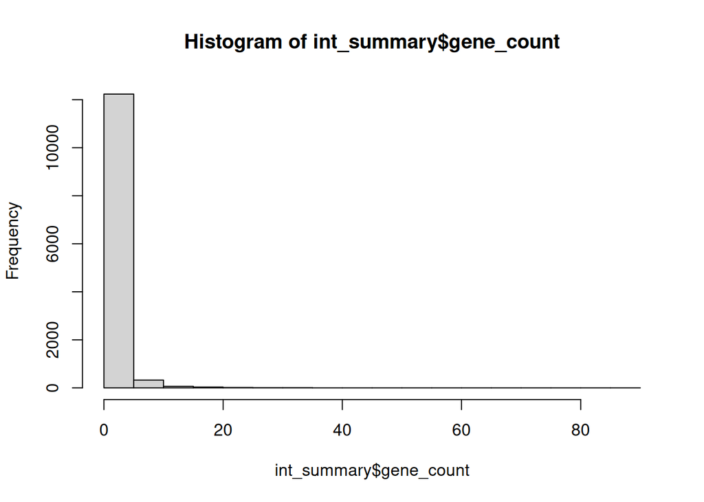

```r
#Complete dataset Gene Counts
hist(int_summary$gene_count)
```

```r
#All distributions are heavily skewed. So, parametric tests are not appropriate. Instead, perform permutations from observed distributions to determine if AM relationship is stronger than that observed in complete dataset. Perform permutations to observed if strength of AM relationship is stronger than random.

#observed relationship between am-specific orthogroup size and frequency of significant interactive expression
(freq_v_gen = cor.test(am_summary$freq, am_summary$gene_count, method = "spearman"))
```

```
##
##  Spearman's rank correlation rho
##
## data:  am_summary$freq and am_summary$gene_count
## S = 8563463, p-value = 0.06997
## alternative hypothesis: true rho is not equal to 0
## sample estimates:
##        rho
## 0.09257664
```

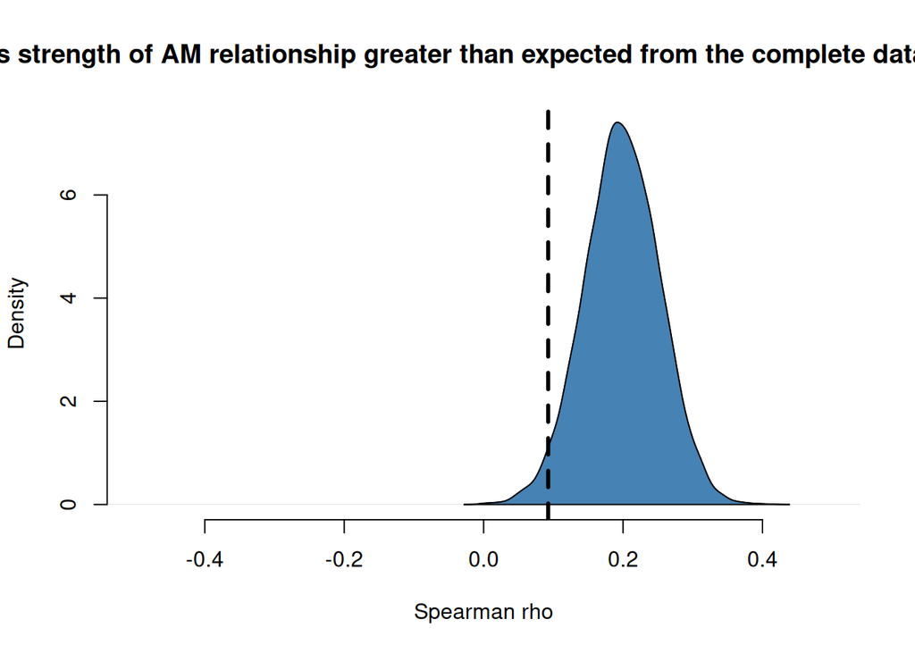

```r
#Is strength of AM relationship greater than expected from the complete dataset?
perm_rho = rep(0, 10000)
for (i in 1:10000) {
  random_df = int_summary[sample(1:nrow(int_summary), length(am_summary$orthogroup)),]
  holder = cor.test(random_df$freq, random_df$gene_count, method = "spearman")
  perm_rho[i] = holder$estimate[[1]]
}
dens = density(perm_rho)
plot(dens, xlim = c(-.5, .5), main = "Is strength of AM relationship greater than expected from the complete dataset?", xlab = "Spearman rho",
     frame = FALSE)
polygon(dens, col = "steelblue")
abline(v = freq_v_gen$estimate[[1]], col = "black", lwd = 3, lty = 2)
```

```r
(pvalue = sum(abs(freq_v_gen$estimate[[1]]) <= abs(perm_rho))/length(perm_rho))
```

```
## [1] 0.9744
```

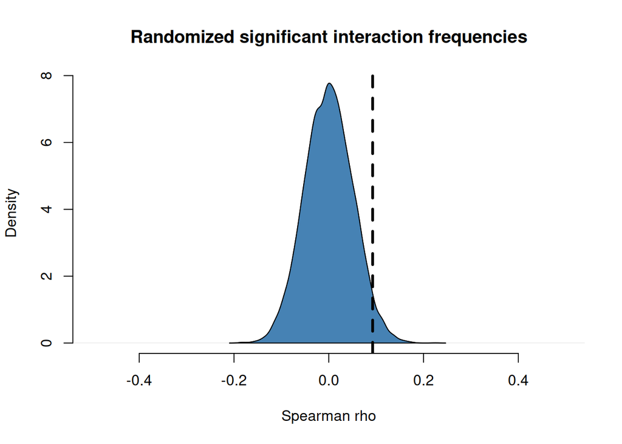

```r
#save this to dataframe for comparing all experiments later.
df_to_save = data.frame(perm_rho, rep(freq_v_gen$estimate, length(perm_rho)), rep("ren2019_root", length(perm_rho)))
colnames(df_to_save) = c("permuted_rho", "observed_rho", "data_source")
write.csv(df_to_save, "processed_data/recchia2018_root.csv")

#Is strength of AM relationship greater than random?
perm_rho = rep(0, 10000)
for (i in 1:10000) {
  random_count = sample(am_summary$gene_count)
  holder = cor.test(am_summary$freq, random_count, method = "spearman")
  perm_rho[i] = holder$estimate[[1]]
}
dens = density(perm_rho)
plot(dens, xlim = c(-.5, .5), main = "Randomized significant interaction frequencies", xlab = "Spearman rho",
     frame = FALSE)
polygon(dens, col = "steelblue")
abline(v = freq_v_gen$estimate[[1]], col = "black", lwd = 3, lty = 2)
```

```r
(pvalue = sum(abs(freq_v_gen$estimate[[1]]) <= abs(perm_rho))/length(perm_rho))
```

```
## [1] 0.0658
```

### Ren 2019 (Salinity, Sesbania cannabina)

```r
#clear environment
rm(list = ls())

#merge the counts from the different dataframes
file_names = list.files("../GOAL3_context_dependent_expression_analysis/raw_data/ren_2019/", pattern = "*.txt")
featurecounts_long = do.call(rbind, lapply(paste("../GOAL3_context_dependent_expression_analysis/raw_data/ren_2019/", file_names, sep = ""), read.table, sep = "\t", header = TRUE))
featurecounts_long = featurecounts_long[, -c(4)]
featurecounts = dcast(featurecounts_long, gene_id ~ Sample_name, value.var = "Read_count")
row.names(featurecounts) = featurecounts$gene_id
featurecounts = featurecounts[,-c(1)]

#load metadata
exp_metadata = read.csv("../GOAL3_context_dependent_expression_analysis/metadata/ren2019_metadata.csv", header = TRUE, row.names = 1)

#put metadata in order of column names from gene counts matrix
all(rownames(exp_metadata) %in% colnames(featurecounts)) #check all samples are in counts
```

```
## [1] TRUE
```

```r
all(rownames(exp_metadata) == colnames(featurecounts)) #check samples are in order
```

```
## [1] TRUE
```

```r
featurecounts = featurecounts[, rownames(exp_metadata)] #put data in same order if the first is true but the second is false

#order factor levels for DESeq to know which is the reference group
exp_metadata$myco = factor(exp_metadata$myco, levels = c("control", "myco"))
exp_metadata$salinity = factor(exp_metadata$salinity, levels = c("control", "salinity"))
exp_metadata$time = factor(exp_metadata$time, levels = c(0, 3, 27))

#split datasets into roots and leaves and analyze separately
exp_root = exp_metadata[exp_metadata$tissue == "root",]
exp_leaf = exp_metadata[exp_metadata$tissue == "shoot",]

featurecounts_root = featurecounts[, colnames(featurecounts) %in% row.names(exp_root)]
featurecounts_leaf = featurecounts[, colnames(featurecounts) %in% row.names(exp_leaf)]

all(rownames(exp_root) %in% colnames(featurecounts_root)) #check all samples are in counts
```

```
## [1] TRUE
```

```r
all(rownames(exp_root) == colnames(featurecounts_root)) #check samples are in order
```

```
## [1] TRUE
```

```r
all(rownames(exp_leaf) %in% colnames(featurecounts_leaf)) #check all samples are in counts
```

```
## [1] TRUE
```

```r
all(rownames(exp_leaf) == colnames(featurecounts_leaf)) #check samples are in order
```

```
## [1] TRUE
```

```r
#load in orthogroup statistics to identify am-specific orthogroups
ortho = read.csv("processed_data/am_res.csv")
am_ortho = ortho

#load data in to DESeq object
#expected counts are outputs from RSEM according to Ren et al 2019. As a result, we can round them.
dds = DESeqDataSetFromMatrix(countData = round(featurecounts_root),
                                 colData = exp_root,
                                 design = ~myco*time #Ask Michelle
                                 )
#remove low count reads (optional, but I'm doing it)
keep = rowSums(counts(dds)) >= 10
dds = dds[keep,]

#perform differential expression analysis
dds_analysis = DESeq(dds, test = "LRT", reduced = ~1)
```

```
## -- note: fitType='parametric', but the dispersion trend was not well captured by the
##    function: y = a/x + b, and a local regression fit was automatically substituted.
##    specify fitType='local' or 'mean' to avoid this message next time.
```

```r
results = results(dds_analysis, alpha = 0.05)
int_analysis = DESeq(dds, test = "LRT", reduced = ~myco+time)
```

```
## -- note: fitType='parametric', but the dispersion trend was not well captured by the
##    function: y = a/x + b, and a local regression fit was automatically substituted.
##    specify fitType='local' or 'mean' to avoid this message next time.
```

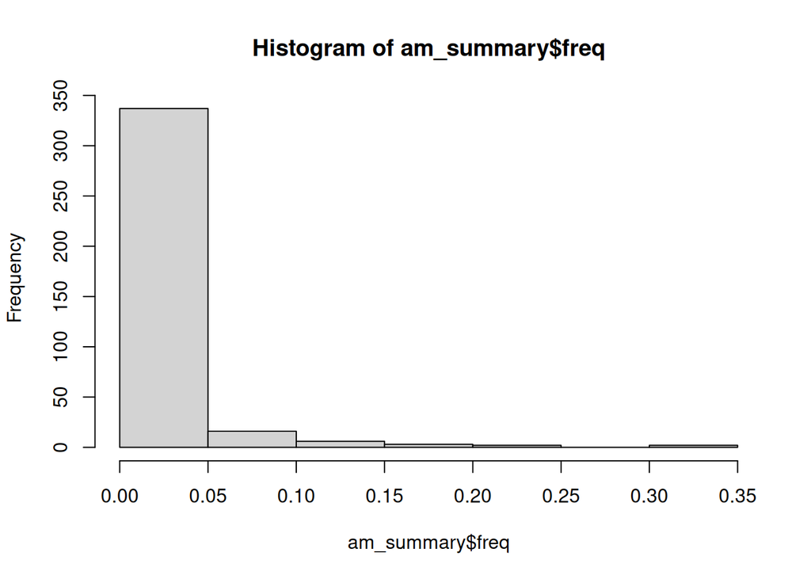

```r
int_results = results(int_analysis, alpha = 0.05)

#load in genome metadata
#note: there are duplicates because there are multiple isoforms for each gene in the genome metadata.
#fix by getting isoform with lowest e-value
gen_data = read.table("../GOAL3_context_dependent_expression_analysis/processed_data/20210713_sesbania_cannabina_blast_with_orthogroup.tsv", sep = "\t", header = TRUE)
gen_data = gen_data[order(gen_data$sesbania_gene, gen_data$evalue, decreasing = FALSE),] #sort by sesbania_gene to group genes together and then by evalue
gen_unique <- gen_data[!duplicated(gen_data$sesbania_gene),] #this should be the same length as gen_data

#get gene counts per orthogroup in triticum
gene_counts = gen_unique %>%
                group_by(orthogroup) %>%
                dplyr::summarise(count = n())

#remove plastid genes
med_ortho = read.csv("../GOAL3_context_dependent_expression_analysis/metadata/orthogroup_identified_AM_medicago_truncatula_genome_metadata.tsv", sep = "\t")
plastid = med_ortho[med_ortho$X.Replicon.Name == "Pltd",]
gene_counts = gene_counts[!(gene_counts$orthogroup %in% plastid$Orthogroup),]

am_gene_counts = gene_counts[gene_counts$orthogroup %in% am_ortho$ortho,]

#merge the deseq data with the genome metadata
int_results_df = as.data.frame(int_results)
int_composite = merge(int_results_df, gen_unique, by.x = 0, by.y = "sesbania_gene")

#filter for results only in am-specific orthogroups
am_int = int_composite[int_composite$orthogroup %in% am_ortho$ortho,]

#add gene count info to am_int
am_int = merge(am_int, am_gene_counts, by = "orthogroup")

#add boolean column for whether genes were differentially expressed.
#used to calculate frequencies
am_int$de_sig = am_int$padj <= 0.05
am_int$de_sig[is.na(am_int$de_sig)] = FALSE

#summarise relationship between am-specific orthogroup size and significance
#mean is used on the count column because this is just duplicated for each orthogroup value
am_summary = am_int %>%
  group_by(orthogroup) %>%
  dplyr::summarise(de_count = sum(de_sig), freq = sum(de_sig)/mean(count), gene_count = mean(count))

#repeat summarization for full dataset to perform permutational analyses
int_composite = merge(int_composite, gene_counts, by = "orthogroup")
int_composite$de_sig = int_composite$padj <= 0.05
int_composite$de_sig[is.na(int_composite$de_sig)] = FALSE
int_summary = int_composite %>%
  group_by(orthogroup) %>%
  dplyr::summarise(de_count = sum(de_sig), freq = sum(de_sig)/mean(count), gene_count = mean(count))

#Plot distributions of gene counts and frequencies in both summarizations to determine if parametric tests are appropriate or if permutational tests must be used
#AM DE Frequencies
hist(am_summary$freq)
```

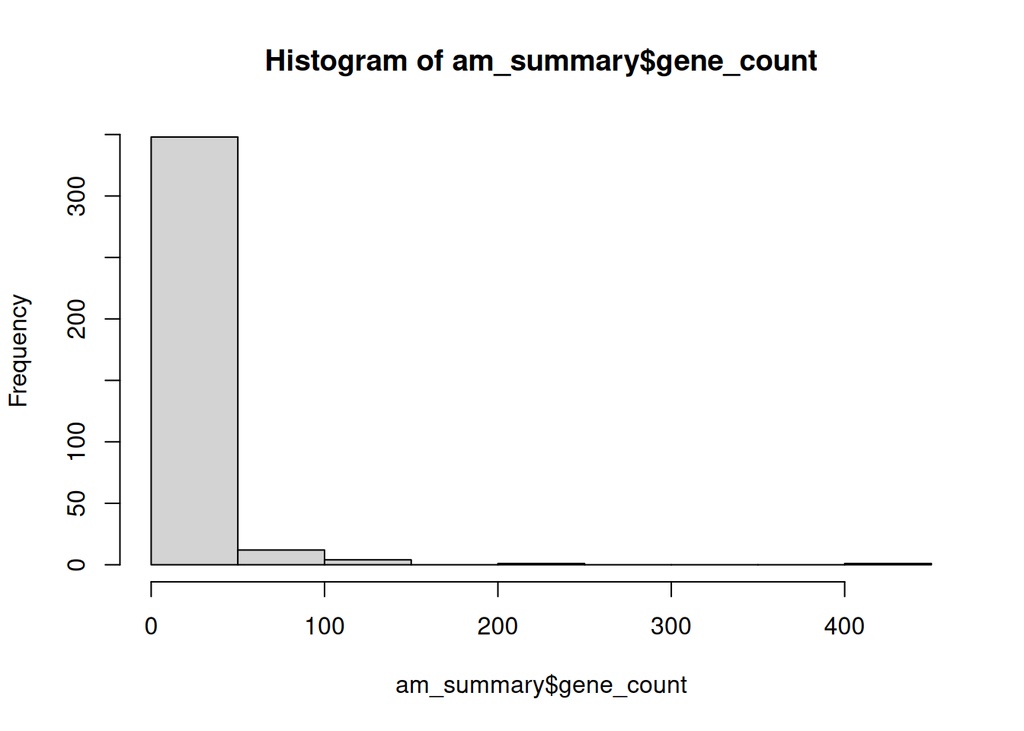

```r
#AM Gene Counts
hist(am_summary$gene_count)
```

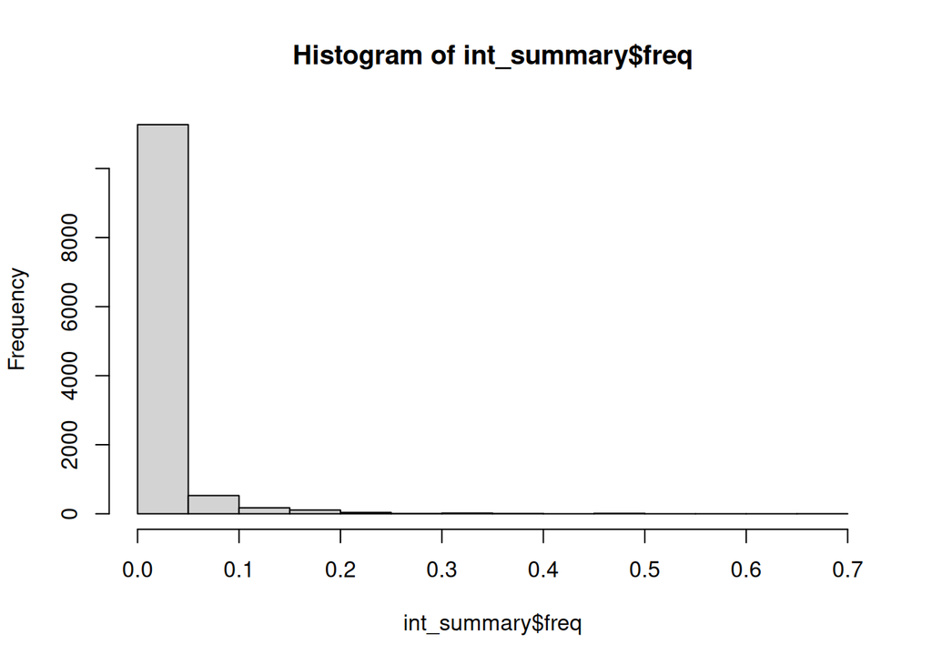

```r
#Complete dataset DE Frequencies
hist(int_summary$freq)
```

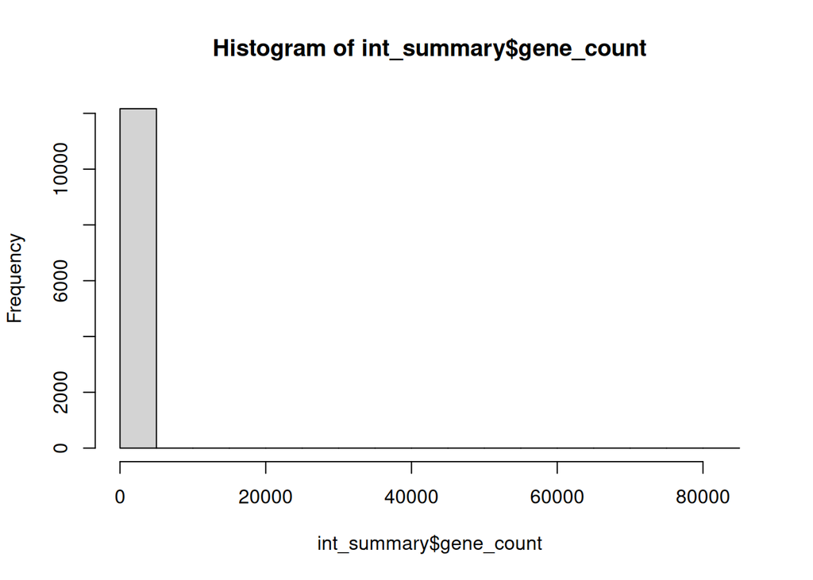

```r
#Complete dataset Gene Counts
hist(int_summary$gene_count)
```

```r
#All distributions are heavily skewed. So, parametric tests are not appropriate. Instead, perform permutations from observed distributions to determine if AM relationship is stronger than that observed in complete dataset. Perform permutations to observed if strength of AM relationship is stronger than random.

#observed relationship between am-specific orthogroup size and frequency of significant interactive expression
(freq_v_gen = cor.test(am_summary$freq, am_summary$gene_count, method = "spearman"))
```

```
##
##  Spearman's rank correlation rho
##
## data:  am_summary$freq and am_summary$gene_count
## S = 5459721, p-value = 7.408e-11
## alternative hypothesis: true rho is not equal to 0
## sample estimates:
##       rho
## 0.3318381
```

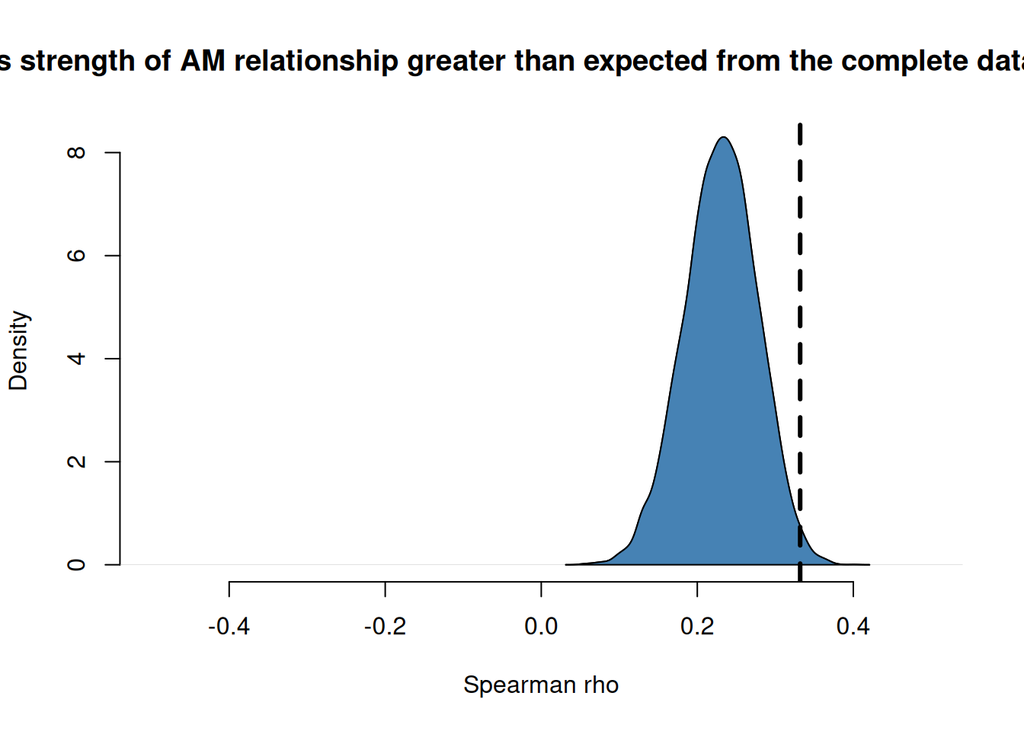

```r
#Is strength of AM relationship greater than expected from the complete dataset?
perm_rho = rep(0, 10000)
for (i in 1:10000) {
  random_df = int_summary[sample(1:nrow(int_summary), length(am_summary$orthogroup)),]
  holder = cor.test(random_df$freq, random_df$gene_count, method = "spearman")
  perm_rho[i] = holder$estimate[[1]]
}
dens = density(perm_rho)
plot(dens, xlim = c(-.5, .5), main = "Is strength of AM relationship greater than expected from the complete dataset?", xlab = "Spearman rho",
     frame = FALSE)
polygon(dens, col = "steelblue")
abline(v = freq_v_gen$estimate[[1]], col = "black", lwd = 3, lty = 2)
```

```r
(pvalue = sum(abs(freq_v_gen$estimate[[1]]) <= abs(perm_rho))/length(perm_rho))
```

```
## [1] 0.011
```

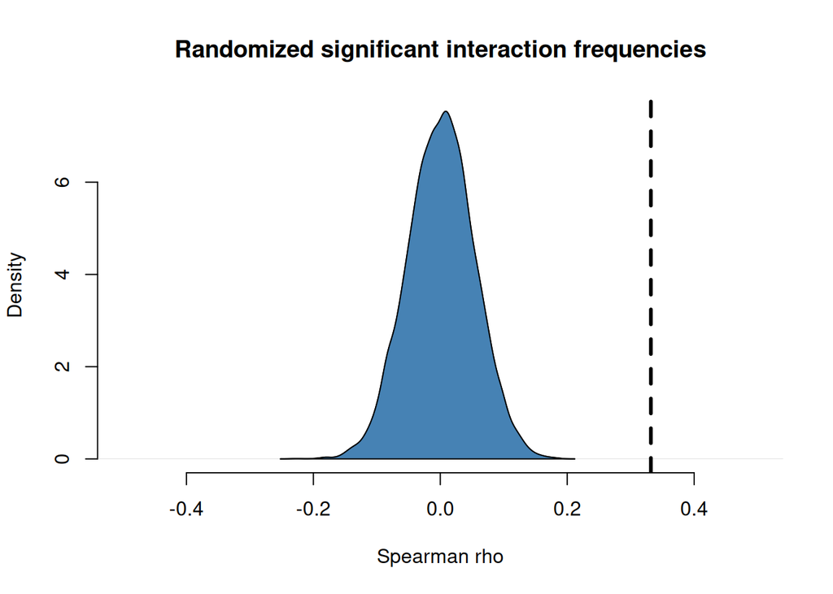

```r
#save this to dataframe for comparing all experiments later.
df_to_save = data.frame(perm_rho, rep(freq_v_gen$estimate, length(perm_rho)), rep("ren2019_root", length(perm_rho)))
colnames(df_to_save) = c("permuted_rho", "observed_rho", "data_source")
write.csv(df_to_save, "processed_data/ren2019_root.csv")

#Is strength of AM relationship greater than random?
perm_rho = rep(0, 10000)
for (i in 1:10000) {
  random_count = sample(am_summary$gene_count)
  holder = cor.test(am_summary$freq, random_count, method = "spearman")
  perm_rho[i] = holder$estimate[[1]]
}
dens = density(perm_rho)
plot(dens, xlim = c(-.5, .5), main = "Randomized significant interaction frequencies", xlab = "Spearman rho",
     frame = FALSE)
polygon(dens, col = "steelblue")
abline(v = freq_v_gen$estimate[[1]], col = "black", lwd = 3, lty = 2)
```

```r
(pvalue = sum(abs(freq_v_gen$estimate[[1]]) <= abs(perm_rho))/length(perm_rho))
```

```
## [1] 0
```

## Larger AM Gene Families as genetic hotspots

```r
#clear environment
rm(list = ls())

#load in GEA results with SNP mappings to genes
gea6p = read.csv("../GOAL4_GWAS/processed_data/20220407_GWAS_pod_output/20220408_GWASResults_Pod_Mapped_SNPS_6pops.csv")
gea7p = read.csv("../GOAL4_GWAS/processed_data/20220407_GWAS_pod_output/20220408_GWASResults_Pod_Mapped_SNPS_7pops.csv")
gea8p = read.csv("../GOAL4_GWAS/processed_data/20220407_GWAS_pod_output/20220408_GWASResults_Pod_Mapped_SNPS_8pops.csv")

#split the gen id to get the jcvi id
gea6p = cbind(gea6p, colsplit(gea6p$gen_id, pattern = "_", names = c("jcvi", "gen_start")))
gea7p = cbind(gea8p, colsplit(gea7p$gen_id, pattern = "_", names = c("jcvi", "gen_start")))
gea8p = cbind(gea8p, colsplit(gea8p$gen_id, pattern = "_", names = c("jcvi", "gen_start")))


#load in map of JCVI gene IDs to RefSeq
jcvi = read.csv("../GOAL4_GWAS/metadata/Medicago_truncatula.MedtrA17_4.0.52.refseq.tsv", sep = "\t")
ortho = read.csv("../GOAL4_GWAS/metadata/orthogroup_identified_AM_medicago_truncatula_genome_metadata.tsv", sep = "\t")
blast_res = read.csv("../GOAL4_GWAS/metadata/20210706_medicago_blast_with_orthogroup.tsv", sep = "\t")
blast_res$X = NULL

#fix jcvi id prefix to match that in HapMap
jcvi$gene_stable_id = gsub("MTR_", "Medtr", jcvi$gene_stable_id)
jcvi = jcvi[grepl("Medtr", jcvi$gene_stable_id),]

#merge jcvi ids to ortho-identified refseq IDs
ortho = merge(jcvi, ortho, by.x = "xref", by.y = "Protein.product", all.x = TRUE)
blast_res = merge(jcvi, blast_res, by.x = "gene_stable_id", by.y = "jcvi", all.x = TRUE)

#filter dataframe to only have genes with refseq protein products
ortho = ortho[grepl("XP_", ortho$xref),]
blast_res = blast_res[grepl("XP_", blast_res$xref),]

#there are a lot of genes that don't match to RefSeq IDs in the original ortho dataframe.
#I checked 12 of them and they were all removed as part of standard genome annotation.
#I will use the results from the BLAST matching which retained most of the annotated genes in the JCVI annotation and genes that did not have a BLAST match to something in an orthogroup was just lumped into "not_in_refseq"
#some genes still do not a match to a RefSeq in the BLAST (~5%). They were mostly genes removed during the genome annotation process. I will remove them from the dataframe here and reclassify them when mapping to GEA results as "not_in_refseq".
blast_res = blast_res[complete.cases(blast_res),]

#use a reduced dataframe that only keeps the jcvi IDs (for matching to GEA results) and the orthogroup identity
#there will be some duplicates because, in the original jcvi dataframe, different isoforms were provided or each gene.
#because we matched by gene id, all the different isoforms will have the same orthogroup identity which is based on the longest isoform
blast_res = blast_res[,c("gene_stable_id","orthogroup")]

blast_res = blast_res %>%
  distinct(.keep_all = TRUE)

#for the first set of analyses, we are excluding intergenic SNPs and not expanding the range of the genome annotations
gea6p = gea6p[!is.na(gea6p$jcvi),]
gea7p = gea7p[!is.na(gea7p$jcvi),]
gea8p = gea8p[!is.na(gea8p$jcvi),]

#add orthogroup identities
gea6p = merge(gea6p, blast_res, by.x = "jcvi", by.y = "gene_stable_id", all.x = TRUE)
gea7p = merge(gea7p, blast_res, by.x = "jcvi", by.y = "gene_stable_id", all.x = TRUE)
gea8p = merge(gea8p, blast_res, by.x = "jcvi", by.y = "gene_stable_id", all.x = TRUE)

#place NAs in orthogroup column in broader "not_in_refseq"
gea6p[is.na(gea6p$orthogroup),"orthogroup"] = "not_in_refseq"
gea7p[is.na(gea7p$orthogroup),"orthogroup"] = "not_in_refseq"
gea8p[is.na(gea8p$orthogroup),"orthogroup"] = "not_in_refseq"

#to make things easier for me to read, let's remove unnecessary columns
gea6p = gea6p[,c("jcvi", "d_pod", "orthogroup")]
gea7p = gea7p[,c("jcvi", "d_pod", "orthogroup")]
gea8p = gea8p[,c("jcvi", "d_pod", "orthogroup")]


#convert FDR corrected p-values to binary
gea6p[,2] = (gea6p[,2] < 0.05)*1
gea7p[,2] = (gea7p[,2] < 0.05)*1
gea8p[,2] = (gea8p[,2] < 0.05)*1

#calculate number of significant SNPs for each gene
sig_snp = function(df) {
  df = df %>%
    group_by(orthogroup, jcvi) %>%
    summarise_all(list(sum))
  return(df)
}
gea6p = as.data.frame(sig_snp(gea6p))
gea7p = as.data.frame(sig_snp(gea7p))
gea8p = as.data.frame(sig_snp(gea8p))

#get gene lengths to normalize snp variation
gene_meta = read.csv("../GOAL4_GWAS/metadata/mt4-0_jcvi/data/GCA_000219495.2/genomic.gtf", sep = "\t", header = FALSE, skip = 4)

#drop last row of gene_meta which is formatting from gtf file
gene_meta = gene_meta[1:(length(row.names(gene_meta))-1),]

#only select "gene" entries. the "exon" entries are subsections of the gene and anything that is not a gene was not used in the analysis.
gene_meta = gene_meta[gene_meta$V3 == "gene",]

#split description column by ; delimiter
gene_meta = cSplit(indt = gene_meta, splitCols = "V9", sep = ";")

#subset gene_meta to only relevant columns
gene_meta = gene_meta[,c(4,5,14)]
colnames(gene_meta) = c("jcvi_start", "jcvi_stop", "jcvi")
gene_meta$jcvi = gsub("note ", "", gene_meta$jcvi)
gene_meta$jcvi_len = abs(gene_meta$jcvi_stop - gene_meta$jcvi_start)

#for duplicate gene ids, only select the longest annotation
gene_meta = gene_meta %>%
  group_by(jcvi) %>%
  summarise(jcvi_len = max(jcvi_len))

#add gene lengths to SNP dataframes
gea6p = merge(gea6p, gene_meta, by = "jcvi", all.x = TRUE)
gea7p = merge(gea7p, gene_meta, by = "jcvi", all.x = TRUE)
gea8p = merge(gea8p, gene_meta, by = "jcvi", all.x = TRUE)

#normalize snp variation by gene length
norm6p = gea6p
norm7p = gea7p
norm8p = gea8p

norm6p[,3] = norm6p[,3]/norm6p$jcvi_len
norm7p[,3] = norm7p[,3]/norm7p$jcvi_len
norm8p[,3] = norm8p[,3]/norm8p$jcvi_len

#load orthogroup identity
am_ortho = read.csv("../GOAL4_GWAS/metadata/orthogroup_mannwhitney.csv")
am_res = read.csv("processed_data/am_res.csv")

ortho_ident = (am_ortho$X %in% am_res$ortho)
ortho_ident[ortho_ident == TRUE] = "AM"
ortho_ident[ortho_ident == "FALSE"] = "NM"
am_ortho$am_ident = ortho_ident

am_ortho = am_ortho[,c("X", "am_ident")]
colnames(am_ortho)[1] = "orthogroup"

#add orthogroup identities to normalized dataframes
norm6p = merge(norm6p, am_ortho, by = "orthogroup", all.x = TRUE)
norm7p = merge(norm7p, am_ortho, by = "orthogroup", all.x = TRUE)
norm8p = merge(norm8p, am_ortho, by = "orthogroup", all.x = TRUE)

#summarise counts based on jcvi annotations for the orthogroups
#orthogroup identities are consistent across the normalized dataframes
ortho_count = norm6p %>%
  group_by(orthogroup) %>%
  summarise(gene_count = n())

norm6p = merge(norm6p, ortho_count, by = "orthogroup", all.x = TRUE)
norm7p = merge(norm7p, ortho_count, by = "orthogroup", all.x = TRUE)
norm8p = merge(norm8p, ortho_count, by = "orthogroup", all.x = TRUE)

#for this set of analyses remove genes that were not matched to RefSeq genes
ref6p = norm6p[norm6p$orthogroup != "not_in_refseq",]
ref7p = norm7p[norm7p$orthogroup != "not_in_refseq",]
ref8p = norm8p[norm8p$orthogroup != "not_in_refseq",]

#get list of am-specific orthogroups
am_spec = am_ortho$orthogroup[am_ortho$am_ident == "AM"]
am_spec = am_spec[am_spec %in% unique(ref6p$orthogroup)]

#calculate observed correlations of am-specific orthogroup size and amount of variation
obs6p = rep(0,1)
obs7p = rep(0,1)
obs8p = rep(0,1)
env_names = colnames(norm6p)[3]
obs_df = data.frame(row.names = env_names,
                    obs6p = obs6p,
                    obs7p = obs7p,
                    obs8p = obs8p)

obs_corr = function(obs_out, ref_in, out_col) {
  for(i in row.names(obs_out)) {
    snp_var = ref_in[ref_in$am_ident == "AM", i]
    ortho_size = ref_in[ref_in$am_ident == "AM","gene_count"]
    test = cor.test(as.vector(snp_var), as.vector(ortho_size), method = "spearman")
    obs_out[i, out_col] = test$estimate[[1]]
  }
  return(obs_out)
}

obs_df = obs_corr(obs_df, ref6p, "obs6p")
obs_df = obs_corr(obs_df, ref7p, "obs7p")
obs_df = obs_corr(obs_df, ref8p, "obs8p")

#calculate randomized relationship between orthogroup size and snp variation with random subsampling of orthogroups
env_fact = rep(row.names(obs_df), each = 10000)
env_fact = c(env_fact, env_fact, env_fact)
gea = rep(c("gea6p", "gea7p", "gea8p"), each = 10000*length(row.names(obs_df)))

samp_df = data.frame(perm_count = rep(1:10000, times = length(row.names(obs_df))*3),
                     rand_rho = rep(0, length(row.names(obs_df))*3*10000), #creates an empty column to fill with 10000 permutations by the number of factors by the number of GEAs with different ancestral populations
                     env_fact = env_fact,
                     gea = gea
                     )

samp_corr = function(refin_1, refin_2, refin_3, df_out){
  #samp_ortho variables will randomly select from all orthogroups the same number of orthogroups that are am-specific
  for (i in 1:length(row.names(df_out))){
    samp_ortho = sample(unique(refin_1$orthogroup), length(am_spec))
    if (df_out$gea[i] == "gea6p"){
      snp_var = refin_1[refin_1$orthogroup %in% samp_ortho, df_out$env_fact[i]]
      ortho_size = refin_1[refin_1$orthogroup %in% samp_ortho, "gene_count"]
      test = cor.test(as.vector(snp_var), as.vector(ortho_size), method = "spearman")
      df_out[i, "rand_rho"] = test$estimate[[1]]
    }
    else if (df_out$gea[i] == "gea7p"){
      snp_var = refin_2[refin_2$orthogroup %in% samp_ortho, df_out$env_fact[i]]
      ortho_size = refin_2[refin_2$orthogroup %in% samp_ortho, "gene_count"]
      test = cor.test(as.vector(snp_var), as.vector(ortho_size), method = "spearman")
      df_out[i, "rand_rho"] = test$estimate[[1]]
    }
    else if (df_out$gea[i] == "gea8p"){
      snp_var = refin_3[refin_3$orthogroup %in% samp_ortho, df_out$env_fact[i]]
      ortho_size = refin_3[refin_3$orthogroup %in% samp_ortho, "gene_count"]
      test = cor.test(as.vector(snp_var), as.vector(ortho_size), method = "spearman")
      df_out[i, "rand_rho"] = test$estimate[[1]]
    }
    else {
      print("Something went wrong.")
    }
  }
  return(df_out)
}

samp_df = samp_corr(ref6p, ref7p, ref8p, samp_df)

#fill in column for observed values
samp_df$obs_rho = 0

for (i in row.names(obs_df)){
  samp_df[(samp_df$env_fact == i) & (samp_df$gea == "gea6p"),"obs_rho"] = obs_df[i,"obs6p"]
  samp_df[(samp_df$env_fact == i) & (samp_df$gea == "gea7p"),"obs_rho"] = obs_df[i,"obs7p"]
  samp_df[(samp_df$env_fact == i) & (samp_df$gea == "gea8p"),"obs_rho"] = obs_df[i,"obs8p"]
}

#create boolean column asking if random is greater than or equal to observed
samp_df$great_rand = (samp_df$rand_rho >= samp_df$obs_rho)*1

#summarise by sum of number of random rhos greater than observed
samp_summary = samp_df %>%
  group_by(gea, env_fact) %>%
  summarise(great_rand = list(sum(great_rand)))
```

[output not shown]

```r
samp_summary$great_rand = as.numeric(samp_summary$great_rand)
samp_summary$p_value = samp_summary$great_rand/10000

#split into the different geas for fdr correction (maybe?)
summary6p = samp_summary[samp_summary$gea == "gea6p",]
summary7p = samp_summary[samp_summary$gea == "gea7p",]
summary8p = samp_summary[samp_summary$gea == "gea8p",]

summary6p$fdr = p.adjust(summary6p$p_value, method = "fdr")
summary7p$fdr = p.adjust(summary7p$p_value, method = "fdr")
summary8p$fdr = p.adjust(summary8p$p_value, method = "fdr")

samp_summary = rbind(summary6p, summary7p, summary8p)

#order factors for plotting. Group soil characteristics together for interpretation
samp_summary$gea = factor(samp_summary$gea, levels = c("gea6p", "gea7p", "gea8p"))
samp_summary$env_fact = factor(samp_summary$env_fact, levels = c("d_pod"))

samp_df$gea = factor(samp_df$gea, levels = c("gea6p", "gea7p", "gea8p"))
samp_df$env_fact = factor(samp_df$env_fact, levels = c("d_pod"))

#summarise by sum of number of random rhos greater than observed
obs_long = samp_df %>%
  group_by(gea, env_fact) %>%
  summarise(obs_rho = list(mean(obs_rho)))
```

[output not shown]

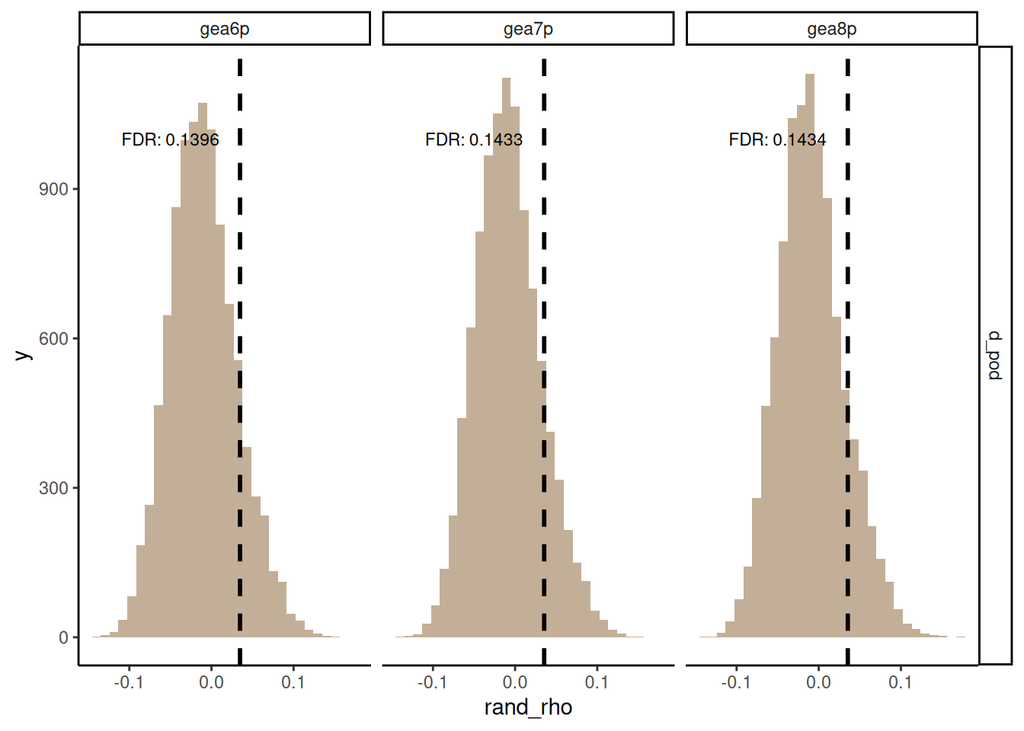

```r
obs_long$obs_rho = as.numeric(obs_long$obs_rho)

samp_summary$fdr_plot = paste("FDR: ", as.character(round(samp_summary$fdr, 4)), sep = "")

ggplot(data = samp_df) +
  facet_grid(rows = vars(env_fact), cols = vars(gea)) +
  geom_histogram(aes(rand_rho), fill = "#c3af97") +
  geom_vline(data = obs_long, aes(xintercept = obs_rho), linetype = "dashed", size = 1) +
  geom_text(data = samp_summary, aes(-.05, 1000, label = fdr_plot), size = 3) +
  theme_classic()
```

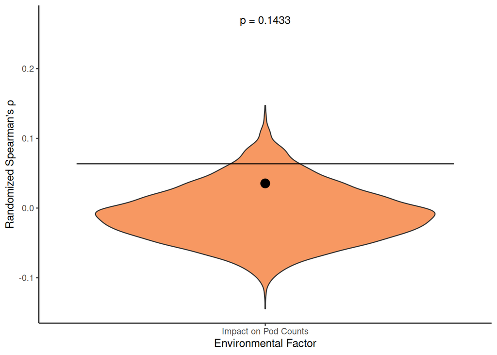

```r
plot7 = samp_df[samp_df$gea == "gea7p",]

#get upper cut-off for 95% of randomized data to plot where the significance threshold is in the violing plot
quant_df = plot7 %>%
  group_by(env_fact) %>%
  summarise(quant95 = quantile(rand_rho, c(.95)))

#reorder summary7p to match the order in the plot
summary7 = samp_summary[samp_summary$gea == "gea7p",]
summary7 = summary7[match(quant_df$env_fact, summary7$env_fact),]
summary7$p_plot = paste("p = ", as.character(round(summary7$p_value, 4)), sep = "")

# ggplot(plot7, aes(x = env_fact, y = rand_rho)) +
#   geom_violin(aes(alpha = env_fact), fill = "#f79862") +
#   scale_alpha_manual(values = c(1, 1, 1, .5, .5)) +
#   geom_point(data = obs_long[obs_long$gea == "gea7p",], aes(x = env_fact, y = obs_rho), size = 4, alpha = c(1, 1, 1, .5, .5)) +
#   geom_segment(data = quant_df, aes(x = seq(0.5, 4.5, by = 1), xend = seq(1.5, 5.5, by = 1), y = as.vector(quant_df$quant95), yend = as.vector(quant_df$quant95)), color = "black") +
#   labs(x = "Environmental Factor", y = "Randomized Spearman's \u03C1") +
#   scale_x_discrete(labels = c("Labile P", "Soil N", "Soil pH", "Highest Precipitation", "Temperature Range")) +
#   annotate("text", x = 1:5, y = .27, label = summary7$p_plot) +
#   theme_classic() +
#   theme(legend.position = "none")

ggplot(plot7, aes(x = env_fact, y = rand_rho)) +
  geom_violin(fill = "#f79862") +
  geom_point(data = obs_long[obs_long$gea == "gea7p",], aes(x = env_fact, y = obs_rho), size = 4) +
  geom_segment(data = quant_df, aes(x = c(0.5), xend = c(1.5), y = as.vector(quant_df$quant95), yend = as.vector(quant_df$quant95)), color = "black") +
  labs(x = "Environmental Factor", y = "Randomized Spearman's \u03C1") +
  scale_x_discrete(labels = c("Impact on Pod Counts")) +
  annotate("text", x = 1, y = .27, label = summary7$p_plot) +
  theme_classic() +
  theme(legend.position = "none")
```

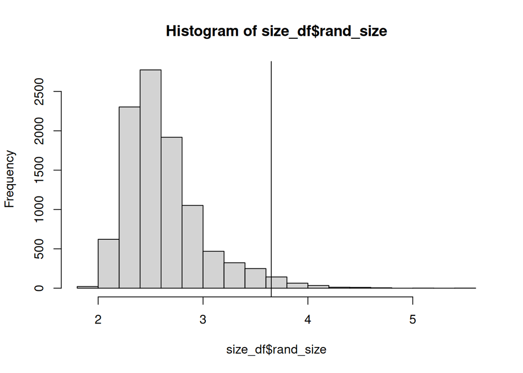

```r
## Could AM orthogroups be unique in size?
size_df = data.frame(perm_count = rep(1:10000),
                     rand_size = rep(0, 10000)
                     )

ortho_size_df = ref7p %>%
  group_by(orthogroup) %>%
  summarise(avg_size = mean(gene_count))

for (i in 1:10000) {
  size_df[i,"rand_size"] = mean(sample(ortho_size_df$avg_size, length(am_spec)))
}

hist(size_df$rand_size)
abline(v = mean(ortho_size_df[ortho_size_df$orthogroup %in% am_spec,]$avg_size))
```

```r
sum(size_df$rand_size > mean(ortho_size_df[ortho_size_df$orthogroup %in% am_spec,]$avg_size))/10000
```

```
## [1] 0.0225
```

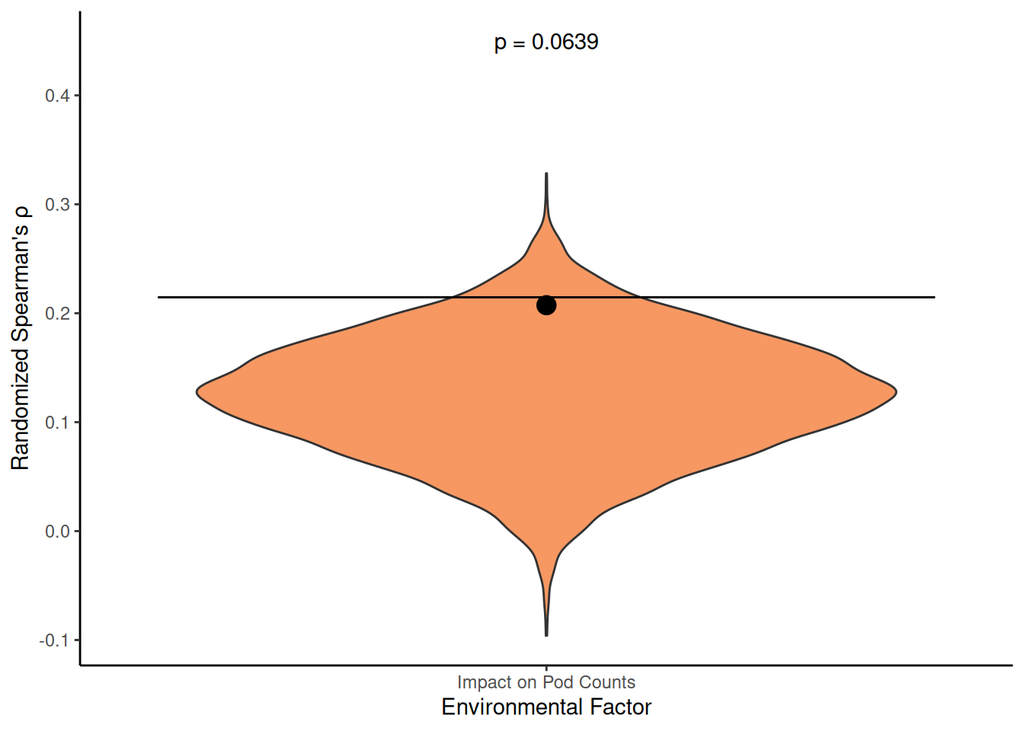

```r
### Repeat SNP variation relationships by relating SNP variation ACROSS the whole orthogroup
ortho7 = gea7p[gea7p$orthogroup != "not_in_refseq", 2:length(colnames(gea7p))]

ortho7 = group_by(ortho7, orthogroup) %>%
  summarise_all(sum)

ortho7[,2] = ortho7[,2]/ortho7$jcvi_len

ortho_corr = rep(0,1)
names(ortho_corr) = colnames(ortho7[,2])

ortho7 = merge(ortho7, ortho_count, by = "orthogroup", all.x = TRUE)

for (i in colnames(ortho7)[2]) {
  holder = ortho7[ortho7$orthogroup %in% am_spec,]
  holder_test = cor.test(as.vector(holder[,i]), holder$gene_count, method = "spearman")
  ortho_corr[i] = holder_test$estimate
}

#subsampling analysis
env_fact = rep("d_pod", each = 10000)

samp_df_ortho = data.frame(perm_count = rep(1:10000, times = 1),
                     rand_rho = rep(0, 10000), #creates an empty column to fill with 10000 permutations by the number of factors by the number of GEAs with different ancestral populations
                     env_fact = env_fact
                     )

for (i in 1:length(row.names(samp_df_ortho))) {
  ortho_samp = sample(ortho7$orthogroup, length(am_spec))
  holder = ortho7[ortho7$orthogroup %in% ortho_samp,]
  holder_test = cor.test(as.vector(holder[,samp_df_ortho[i,"env_fact"]]), holder$gene_count, method = "spearman")
  samp_df_ortho[i,"rand_rho"] = holder_test$estimate
}

#plotting
ortho_corr = as.data.frame(ortho_corr)
ortho_corr$env_fact = row.names(ortho_corr)

ortho_quant_df =  samp_df_ortho %>%
  group_by(env_fact) %>%
  summarise(quant95 = quantile(rand_rho, c(.95)))

samp_df_ortho$env_fact = factor(samp_df_ortho$env_fact, levels = c("d_pod"))
ortho_corr$env_fact = factor(ortho_corr$env_fact, levels = c("d_pod"))
ortho_quant_df$env_fact = factor(ortho_quant_df$env_fact, levels = c("d_pod"))

#reorder ortho_corr and ortho_quant_df to match the order for plotting
ortho_corr = ortho_corr[order(ortho_corr$env_fact),]
ortho_quant_df = ortho_quant_df[order(ortho_quant_df$env_fact),]

ortho_p = merge(samp_df_ortho, ortho_corr, by = "env_fact")
ortho_p$ortho_bool = (ortho_p$rand_rho >= ortho_p$ortho_corr) * 1
ortho_p = group_by(ortho_p, env_fact) %>%
  summarise(p_value = sum(ortho_bool)/10000)
ortho_p$p_plot = paste("p = ", as.character(round(ortho_p$p_value, 4)), sep = "")

ggplot(samp_df_ortho, aes(x = env_fact, y = rand_rho)) +
  geom_violin(fill = "#f79862") +
  geom_point(data = ortho_corr, aes(x = env_fact, y = ortho_corr), size = 4) +
  geom_segment(data = ortho_quant_df, aes(x = c(0.5), xend = c(1.5), y = quant95, yend = quant95), color = "black") +
  labs(x = "Environmental Factor", y = "Randomized Spearman's \u03C1") +
  scale_x_discrete(labels = c("Impact on Pod Counts")) +
  annotate("text", x = 1, y = .45, label = ortho_p$p_plot) +
  theme_classic() +
  theme(legend.position = "none")
```

## Gene Duplication Analyses

```r
#clear environment
rm(list = ls())

#Modified from https://www.r-bloggers.com/2012/11/expand-delimited-columns-in-r/ to expand the comma delimited columns in the Orthogroup metadata.
#For some reason, I can't get cSplit in splitstackshape to do it correctly. Even though I call the species column with the orthogroup metadata, it keeps trying to split up the orthogroup ID column.

#Function to expand data
expand.delimited <- function(x, col1, col2, sep=",") {
  rnum <- 1
  expand_row <- function(y) {
    factr <- y[col1]
    strng <- toString(y[col2])
    expand <- strsplit(strng, sep)[[1]]
    num <- length(expand)
    factor <- rep(factr,num)
    return(as.data.frame(cbind(factor,expand),
          row.names=seq(rnum:(rnum+num)-1)))
    rnum <- (rnum+num)-1
  }
  expanded <- apply(x,1,expand_row)
  df <- do.call("rbind", expanded)
  names(df) <- c(names(x)[col1],names(x)[col2])
  return(df)
}

#get list of species that were in OrthoFinder analysis
am_ortho_df = read.csv("../GOAL5_duplication_origin_analysis/metadata/orthogroup_mannwhitney.csv")

specs = colnames(am_ortho_df)[grepl("AM_", colnames(am_ortho_df))]

#get list of AM orthogroups
am_ortho = read.csv("processed_data/am_res.csv")

#dir.create("processed_data/duplication_tables")

for (spec in specs) {
  ref_label = spec
  spec = gsub("_refseq", "", spec)

  df_c = read.table(paste("../GOAL5_duplication_origin_analysis/processed_data/",spec,"/",spec,".gff", sep = ""), sep = "\t")
  colnames(df_c) = c("chrom", "gene", "start", "end")

  #get orthogroup classifications
  orth_c = read.table("../GOAL5_duplication_origin_analysis/metadata/Orthogroups.csv", sep = "\t", header = TRUE)

  #reduce orthogroup dataframe to species of interest
  orth_c = orth_c[,c("X", ref_label)]

  #remove orthogroups that don't occur in the species
  orth_c = orth_c[orth_c[, ref_label] != "",]

  #remove whitespace in species column
  orth_c[,ref_label] = gsub('\\s+', '', orth_c[,ref_label])

  #expand gene id info into columns
  orth_c = data.frame(expand.delimited(orth_c, "X", ref_label))
  colnames(orth_c) = c("ortho", "gene")

  #use refseq ID as gene name to match gff file
  orth_c = orth_c %>%
    separate(gene, c("gi_name", "gi", "ref", "gene", "blank"), "\\|") %>%
    select(c(ortho, gene))

  #add orthogroup information to bed file
  df_c = merge(df_c, orth_c, by = "gene", all.x = TRUE)

  #For now I am going to remove those with NAs in the ortho column and move on with doing the duplicate gene classification.
  df_c = df_c[!is.na(df_c$ortho),]

  #for this round I am removing scaffolds that have less than three genes (i.e., the minimum for determining wgd/segmental duplication)
  #discuss with Michelle if this is a good idea because it's unclear what kind of duplication event they would be part of.
  chrom_count = df_c %>%
    group_by(chrom) %>%
    summarise(count = n())

  chrom_ok = chrom_count$chrom[chrom_count$count >= 3]

  df_c = df_c[df_c$chrom %in% chrom_ok,]

  #group by chromosome/scaffold
  df_c = df_c %>%
    group_by(chrom)

  #sort chromosome by gene start
  df_c = df_c %>%
    arrange(start, .by_group = TRUE)

  #remove mitochondrial/plastid chromosomes if there are any
  df_c = df_c[!grepl("YP", df_c$gene),]

  #get gene ranks along chromosome
  df_c = df_c %>%
    mutate(rank = rank(start))

  #create empty columns to store booleans for the different gene duplication classes
  df_c$singleton = TRUE
  df_c$dispersed = FALSE
  df_c$proximal = FALSE
  df_c$tandem = FALSE
  df_c$segmental = FALSE

  ## DISPERSED
  #So, if a gene is dispersed it must have an orthogroup size larger than 1.
  #We will first make all non-singleton orthogroups dispersed and then change the classification as we go through the tests for the higher priority classificiations
  ortho_mult = df_c %>%
    ungroup() %>%
    group_by(ortho) %>%
    summarise(count = n())

  ortho_mult_vec = ortho_mult$ortho[ortho_mult$count > 1]

  df_c$singleton[df_c$ortho %in% ortho_mult_vec] = FALSE
  df_c$dispersed[df_c$ortho %in% ortho_mult_vec] = TRUE

  ## TANDEM/PROXIMAL
  #Now we will reclassify the dispersed classifications is genes are tandem or proximal. Meaning that genes are either next to each other (tandem) or separated by 20 genes or less (proximal; original MCScanX paper, but can be changed).

  #make vector of orthogroups that cannot be tandem or proximal
  #vector of orthogroups that only occur once on each chromosome (i.e., singleton or not possible to be close to each other since they are on separate chromosomes)
  ortho_chrom_count = df_c %>%
    ungroup() %>%
    group_by(chrom, ortho) %>%
    summarise(count = n()) %>%
    ungroup() %>%
    group_by(ortho) %>%
    summarise(max = max(count))

  too_far = ortho_chrom_count$ortho[ortho_chrom_count$max == 1]

  #to speed up pairwise difference calculations, let's remove the ones that absolutely cannot be tandem/proximal
  temp_df = df_c[!(df_c$ortho %in% too_far),]

  #for each orthogroup within a chromosome, make a numeric matrix of pairwise differences in rank
  dist_df = data.frame(row = factor(), col = factor(), value = numeric())
  for (c in unique(temp_df$chrom)) {
    holder = temp_df[temp_df$chrom == c,]
    for (o in unique(holder$ortho)) {
      holder2 = holder[holder$ortho == o,]
      ranks = holder2$rank
      names(ranks) = holder2$gene
      dist_hold = melt(as.matrix(dist(ranks)), varnames = c("row", "col"))
      dist_df = rbind(dist_df, dist_hold)
    }
  }

  #remove self-comparisons
  dist_df = dist_df[dist_df$value > 0,]

  #get minimum of each gene to make tandem/proximal classifications
  dist_min = dist_df %>%
    group_by(row) %>%
    summarise(drank_min = min(value))

  #identify tandem (drank_min == 1) and proximal (1 < drank_min <= 20)
  dist_min$dup_class = NA

  dist_min$dup_class[dist_min$drank_min == 1] = "tandem"
  dist_min$dup_class[dist_min$drank_min > 1 & dist_min$drank_min <= 20] = "proximal"

  #get vectors of the two classes and change the df_c dataframe to reflect that
  prox_vec = dist_min$row[dist_min$dup_class == "proximal"]
  tand_vec = dist_min$row[dist_min$dup_class == "tandem"]

  df_c$proximal[df_c$gene %in% prox_vec] = TRUE
  df_c$tandem[df_c$gene %in% tand_vec] = TRUE
  df_c$dispersed[df_c$gene %in% prox_vec | df_c$gene %in% tand_vec] = FALSE

  #export bed file to test MCScanX_h
  gff_c = df_c[,c(2,1,3,4)]

  #make pairwise homology file for MCScanX_h
  hom_c = left_join(orth_c, orth_c, by = "ortho") %>%
    filter(gene.x != gene.y)

  hom_c = hom_c[hom_c$gene.x %in% df_c$gene,]
  hom_c = hom_c[hom_c$gene.y %in% df_c$gene,]
  hom_c = hom_c[,2:3]

  hom_c$gene.x = paste("dc0|", hom_c$gene.x, sep = "")
  hom_c$gene.y = paste("dc0|", hom_c$gene.y, sep = "")

  hom_c$rand = sample(100, size = nrow(hom_c), replace = TRUE)

  #add appendices for names in both gff and homology files for MCScanX_h to do it's thing
  gff_c1 = gff_c
  gff_c1$chrom = paste("dc0_", gff_c1$chrom, sep = "")
  gff_c1$gene = paste("dc0|", gff_c1$gene, sep = "")

  #write necessary files to disk
  dir.create(paste("processed_data/", spec , sep = ""))
  write.table(df_c, paste("processed_data/duplication_tables/", spec, "_dupnowgd.csv", sep = ""), row.names = FALSE, quote = FALSE)

  write.table(gff_c1, paste("processed_data/", spec, "/", spec, "_mcscan_input.gff", sep = ""), sep = "\t", col.names = FALSE, row.names = FALSE, quote = FALSE)

  write.table(hom_c, paste("processed_data/", spec, "/", spec, "_mcscan_input.homology", sep = ""), sep = "\t", col.names = FALSE, row.names = FALSE, quote = FALSE)
}
```

```r
for (spec in specs) {
  spec = gsub("_refseq", "", spec)
  collinearity = read.table(paste("../GOAL5_duplication_origin_analysis/processed_data/", spec, "/", spec, "_mcscan_input.collinearity", sep = ""), comment.char = "#", sep = "\t")

  #we only want the gene names so get rid of the other data
  collinearity = collinearity[,2:3]

  #correct gene name by removing the "dc0|" filler
  collinearity$V2 = gsub("dc0\\|", "", collinearity$V2)
  collinearity$V3 = gsub("dc0\\|", "", collinearity$V3)

  #get list of colinear genes
  colinear_genes = unique(c(collinearity$V2, collinearity$V3))

  #read in the duplication data from before
  df_c = read.csv(paste("processed_data/duplication_tables/", spec, "_dupnowgd.csv", sep = ""), sep = " ")

  #if genes are in the colinear gene list, mark them as segmental in the df_c data record that has all the duplication events
  df_c$segmental = ifelse(df_c$gene %in% colinear_genes, TRUE, FALSE)

  #convert the classifications into numbers so that you can make a max column
  dup_class = df_c

  dup_class$segmental = ifelse(dup_class$segmental == TRUE, 4, NA)
  dup_class$tandem = ifelse(dup_class$tandem == TRUE, 3, NA)
  dup_class$proximal = ifelse(dup_class$proximal == TRUE, 2, NA)
  dup_class$dispersed = ifelse(dup_class$dispersed == TRUE, 1, NA)
  dup_class$singleton = ifelse(dup_class$singleton == TRUE, 0, NA)

  dup_class$num_class = pmax(dup_class$singleton, dup_class$dispersed, dup_class$proximal, dup_class$tandem, dup_class$segmental, na.rm = TRUE)

  #what's the distribution of the classes
  table(dup_class$num_class)
  table(dup_class$num_class)/sum(table(dup_class$num_class))

  dup_class$myco = ifelse(dup_class$ortho %in% am_ortho$ortho, "AM", "NM")

  #get observed percentages of duplication types in the AM orthogroup
  am_dup = dup_class[dup_class$myco == "AM",]

  am_obs = table(am_dup$num_class)/sum(table(am_dup$num_class))

  #randomly subsample from whole genome with same number of am_ortho   groups in am_dup
  null_count = 10000
  rand_obs = data.frame("0" = rep(NA, null_count),
                        "1" = rep(NA, null_count),
                        "2" = rep(NA, null_count),
                        "3" = rep(NA, null_count),
                        "4" = rep(NA, null_count))

  for (i in 1:null_count) {
    hold_ortho = unique(dup_class$ortho)
    rand_ortho = sample(hold_ortho, length(unique(am_dup$ortho)))

    hold_dup = dup_class[dup_class$ortho %in% rand_ortho,]
    hold_obs = table(hold_dup$num_class)/sum(table(hold_dup$num_class))
    names(hold_obs) = paste("X", names(hold_obs), sep = "")
    rand_obs[i,names(hold_obs)] = hold_obs
  }

  colnames(rand_obs) = c("singleton", "dispersed", "proximal", "tandem", "segmental")

  #plot random distributions with observed values for better visualization
  rand_long = gather(rand_obs, dup_class, proportion, singleton:segmental, factor_key = TRUE)

  #save to disk for stats later
  write.csv(rand_long, paste("processed_data/", spec, "_rand-dupevents.csv", sep = ""), quote = FALSE, row.names = FALSE)
  write.csv(dup_class, paste("processed_data/", spec, "_withwgd.csv", sep = ""), quote = FALSE, row.names = FALSE)

  p = ggplot() +
      geom_violin(data = rand_long, aes(x = dup_class, y = proportion)) +
      geom_point(aes(x = 1:5, y = as.vector(am_obs)), size = 3) +
      ggtitle(spec) +
      theme_classic()
  p

  #ggsave(paste("../temp_images/", spec, ".pdf"), plot = p, device = "pdf")
}
```

```r
#get count of scaffolds per species. Species whose genomes are split over too many scaffolds will not be good for WGD analyses
#also get observed ratios of duplication origin types from AM orthogroups
all_am = data.frame("singleton" = rep(NA, length(specs)),
                    "dispersed" = rep(NA, length(specs)),
                    "proximal" = rep(NA, length(specs)),
                    "tandem" = rep(NA, length(specs)),
                    "segmental" = rep(NA, length(specs)),
                    "species" = rep(NA, length(specs))
                    )

scaff_counts = rep(NA, length(specs))
count = 1

all_rand = data.frame("dup_class" = character(),
                      "proportion" = numeric(),
                      "species" = character()
                      )

for (spec in specs) {
  spec = gsub("_refseq", "", spec)
  names(scaff_counts)[count] = spec

  #read in random observations and append with species names
  rand_df = read.csv(paste("processed_data/", spec, "_rand-dupevents.csv", sep = ""))
  rand_df$species = spec
  all_rand = rbind(all_rand, rand_df)

  #read in dup_classes to get scaffold counts and am orthogroup proportions of duplication types
  temp_df = read.csv(paste("processed_data/", spec, "_withwgd.csv", sep = ""))

  scaff_counts[count] = length(unique(temp_df$chrom))

  am_dup = temp_df[temp_df$myco == "AM",]
  all_am[count,1:5] = table(am_dup$num_class)/sum(table(am_dup$num_class))
  all_am[count, "species"] = spec

  count = count + 1
}

#convert all_am to long form
am_long = gather(all_am, dup_class, proportion, singleton:segmental, factor_key = TRUE)

#some of the values are NAs when they should be 0. Not converting them to 0 and using na.rm = TRUE in mean calculation downstream means dividing over fewer categories rather than the full 5 so you overestimate the mean.
all_rand = all_rand %>%
  replace_na(list(proportion = 0))
```

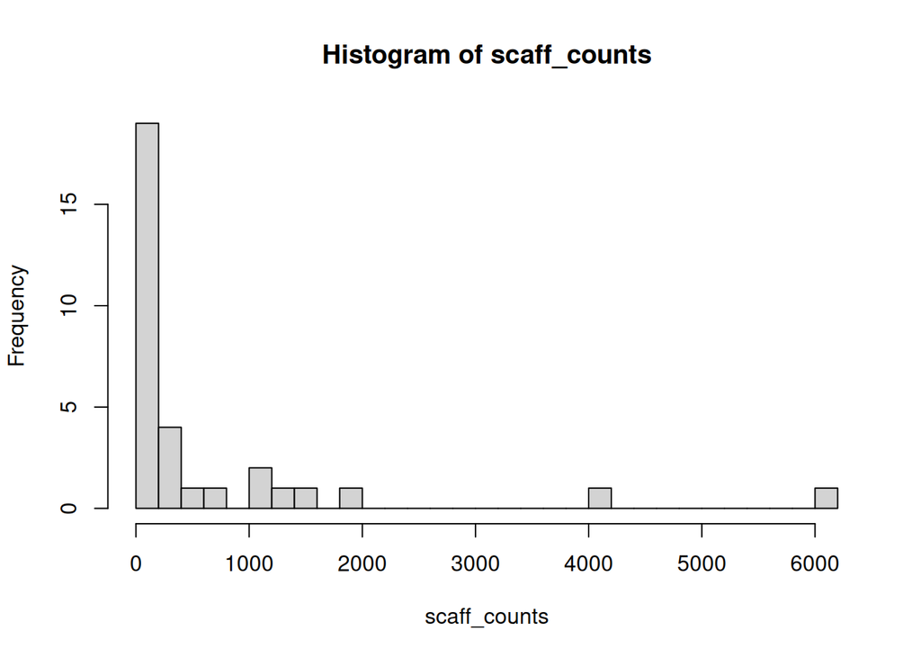

```r
#Find cut-off based on histogram of number of scaffolds to find out where outliers really begin
#I used model species and/or important agricultural crops so the vast majority would have near complete contigs
hist(scaff_counts, breaks = 30)
```

```r
#Based on the histogram, 500 scaffolds seems to be a decent cut-off. We can discuss a better cut-off criterion later because even some of the taxa that had more scaffolds had reasonable distributions of duplication types that matched taxa with fewer scaffolds.
#We lose 8 out of 32 taxa with a cut-off of 500 scaffolds
scaff_filt = scaff_counts[scaff_counts <= 500]

#filter the observed and random dataframes for these taxa that pass the filter.
rand_filt = all_rand[all_rand$species %in% names(scaff_filt),]
am_filt = am_long[am_long$species %in% names(scaff_filt),]
```

```r
dup_p = data.frame("dup_class" = character(),
                   "p_value" = numeric(),
                   "am_observed" = numeric(),
                   "rand_mean" = numeric(),
                   "species" = character()
                   )

count = 1

for (spec in names(scaff_filt)) {
  obs_spec = am_filt[am_filt$species == spec,] %>%
    group_by(dup_class)
  rand_spec = rand_filt[rand_filt$species == spec,] %>%
    group_by(dup_class)

  #absolute difference from random mean for all random values
  rand_bin = rand_spec %>%
    summarise(delta_diff = abs(proportion - mean(proportion)))

  for (i in unique(rand_bin$dup_class)) {
    am_observed = obs_spec[obs_spec$dup_class == i, ]$proportion
    rand_mean = mean(rand_spec[rand_spec$dup_class == i, ]$proportion)

    dup_p[count, "dup_class"] = i
    dup_p[count, "species"] = spec
    dup_p[count, "rand_mean"] = rand_mean
    dup_p[count, "am_observed"] = am_observed


    dup_p[count, "p_value"] = sum(rand_bin[rand_bin$dup_class == i,]$delta_diff > abs(am_observed - rand_mean))/null_count

    count = count + 1
  }
}
```

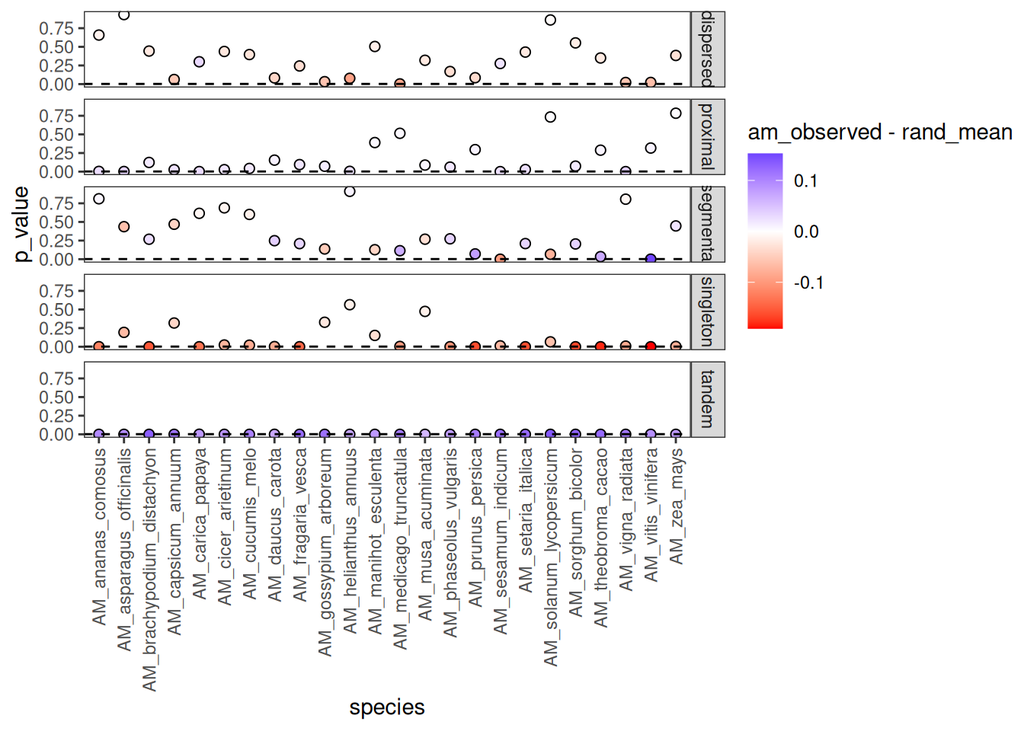

```r
#prettier plotting
(p3 = ggplot(dup_p, aes(species, p_value)) +
  geom_point(aes(fill = am_observed - rand_mean), color = "black", shape = 21, size = 2) +
  scale_fill_gradient2(midpoint = 0, low = "red", mid = "white", high = "blue") +
  facet_grid(vars(dup_class)) +
  theme_test() +
  geom_hline(yintercept = .05/24, linetype = "dashed") +
  scale_x_discrete(guide = guide_axis(angle = 90))
)
```

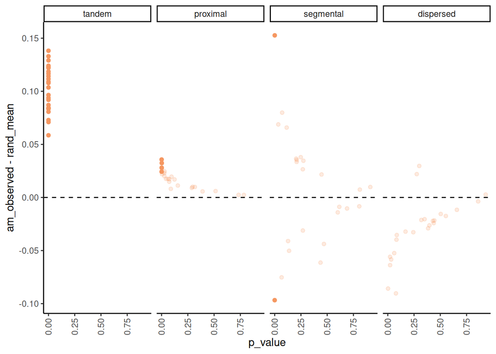

```r
dup_p_filt = dup_p[dup_p$dup_class != "singleton",]
dup_p_filt$dup_class = factor(dup_p_filt$dup_class, levels = c("tandem", "proximal", "segmental", "dispersed"))

(p3 = ggplot(dup_p_filt, aes(p_value, am_observed-rand_mean)) +
  geom_point(aes(alpha = p_value <= .05/24), color = "#f59761") +
  scale_alpha_discrete(range = c(.2, 1)) +
  facet_wrap(vars(dup_class), ncol = 4) +
  theme_classic() +
  theme(legend.position = "none") +
  geom_hline(yintercept = 0, linetype = "dashed") +
  scale_x_continuous(guide = guide_axis(angle = 90))
)
```

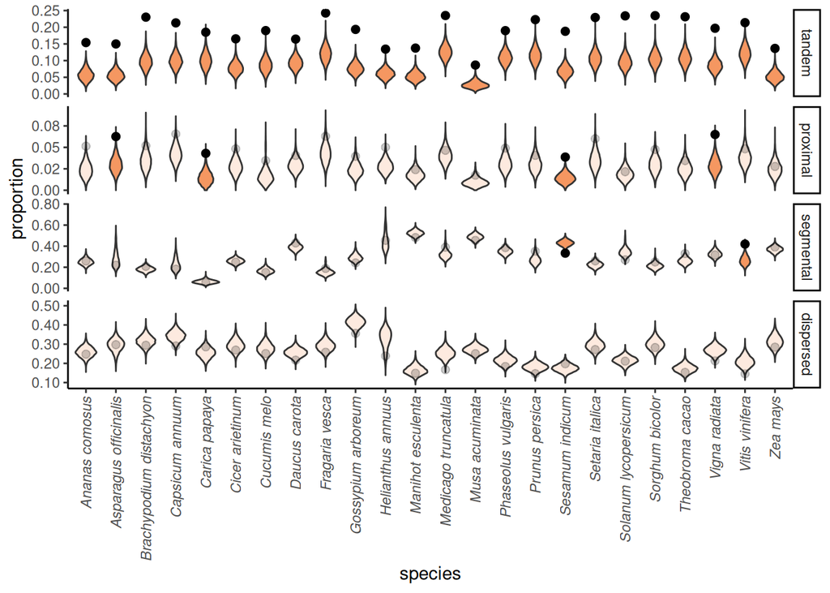

```r
#identify significant groupings
dup_p$significant = dup_p$p_value <= 0.05/length(unique(dup_p$species))

#add significance variable to the all_rand dataframe so that you can highlight which results were significant
all_rand_comb = merge(all_rand, dup_p, by = c("dup_class", "species"))
all_rand_comb = all_rand_comb[all_rand_comb$dup_class != "singleton",]

all_rand_comb$dup_class = factor(all_rand_comb$dup_class, levels = c("tandem", "proximal", "segmental", "dispersed"))

species_names = all_rand_comb %>%
  separate_wider_delim(species, delim = "_", names = c(NA, "genus", "spec"))

species_names = species_names[,c("genus", "spec")]
species_names$genus = capitalize(species_names$genus)
all_rand_comb$species_names = paste(species_names$genus, species_names$spec, sep = " ")

am_long = merge(am_long, dup_p, by = c("dup_class", "species"))

#prettier plotting of random distributions
(p4 = ggplot(all_rand_comb, aes(species, proportion)) +
  geom_violin(aes(alpha = significant), fill = "#f59761") +
  geom_point(data = am_long[(am_long$species %in% unique(all_rand_comb$species)) & (am_long$dup_class != "singleton"),], aes(species, proportion, alpha = significant), size = 2) +
  scale_alpha_discrete(range = c(.2, 1)) +
  facet_grid(rows = vars(dup_class), scales = "free") +
  theme_classic() +
  theme(legend.position = "none") +
  scale_x_discrete(guide = guide_axis(angle = 90), breaks = unique(all_rand_comb$species), labels = unique(all_rand_comb$species_names)) +
  theme(axis.text.x = element_text(face = "italic")) +
  scale_y_continuous(labels = scales::number_format(accuracy = 0.01)))
```